# Python Analysis

# 1 Introduction

In this section, we try to answer our research questions based on the data we have collected for the Python programming language. We attempt to characterize the Python packages by sectors, organizations/institutions, and countries, and also attribute credit towards the most influential actors by aggregating towards these characterization variables. Also, we’d like to construct a package network to see how packages are linked to each other. Finally, we have a number of impact measures (e.g. additions, reverse dependencies…etc) we will use to identify the most important packages in the Python community. A number of impact measures will only be available for the packages we were able to collect GitHub data for (e.g. stars, forks).

```r
library(tidyverse)
library(RMySQL)
library(ggwes)
library(knitr)
library(kableExtra)
library(pander)
library(ggthemes)
library(pbapply)
library(purrr)
library(stringr)
```

# 2 File List

## 2.1 Input Files

```r
python_final <- read.csv("\\\\westat.com\\DFS\\DVSTAT\\Individual Directories\\Askew\\Paper_Data\\python_final.csv") %>%
            dplyr::select(-X)

python_revdep <- read.csv("\\\\westat.com\\DFS\\DVSTAT\\Individual Directories\\Askew\\Paper_Data\\pypi_package_n_reverse_dependencies.csv") %>%
  rename(Package = package,
         Reverse_Depends_Count = reverse_dependencies)
```

### 2.1.1 What is the distribution of unique GitHub Python contributors by sector?

For the 184,444 unique Python contributors on GitHub, we were able to identify a sector for 18,217 of them. 7,322 coming from academic, 9,482 from business, 596 from government, and 817 from nonprofit

```r
python_users_unique <- python_final %>%
                          distinct(login, .keep_all = T)

pander(table(python_users_unique$Sector, useNA = "always"))
```

| Academic | Business | Government | Nonprofit | Unknown | NA |
| --- | --- | --- | --- | --- | --- |
| 7322 | 9482 | 596 | 817 | 166227 | 0 |

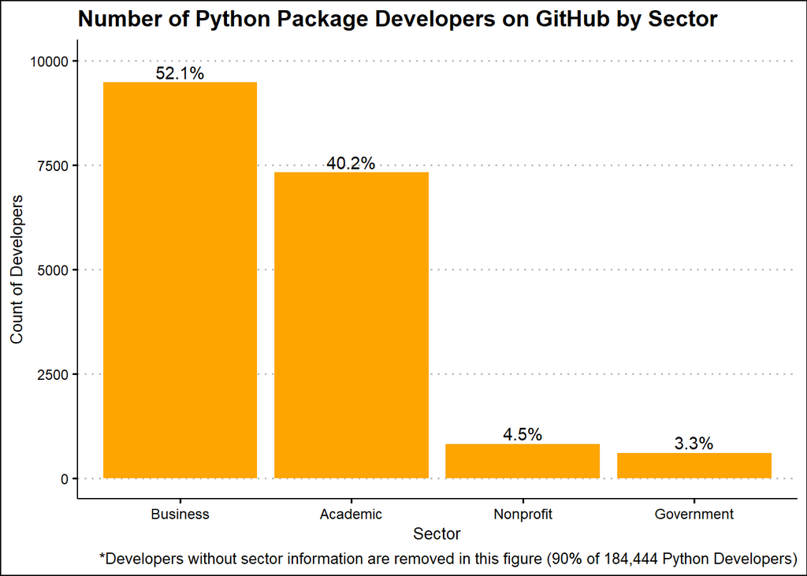

```r
# Calculate counts by sector (All packages on GitHub)
python_user_sector_counts <- python_users_unique %>%
  filter(Sector != "Unknown") %>%
  count(Sector) %>%
  mutate(proportion = n / sum(n),
         proportion_label = paste0(round(proportion * 100, 1), "%")) %>%
  arrange(desc(proportion)) %>%
  mutate(Sector = factor(Sector, levels = unique(Sector)))

# Save plot
python_user_sector_counts_plot <- ggplot(python_user_sector_counts, aes(x = Sector, y = n)) +
  geom_bar(stat = "identity", fill = "orange") +
  geom_text(aes(label = proportion_label), vjust = -0.3) +
  ylab("Count of Developers") +
  ylim(c(0, 10000))+
  ggtitle(label = "Number of Python Package Developers on GitHub by Sector")+
  labs(caption = "*Developers without sector information are removed in this figure (90% of 184,444 Python Developers)")+
  theme_clean()

python_user_sector_counts_plot
```

#### 2.1.1.1 How do we attribute contribution to sectors (equal)?

We now aim to try to attribute contribution to sectors with a couple of methods. First, we look at equal contribution, where each member of a repository is given an equal fraction of credit regardless of level of contribution. So, if a repository has five members, each member will get .2 credit, and then the fractions are aggregated to the sectors. We will count the fraction to unknown sectors as well, but we will remove it in any graphical displays, as we already know this will be the highest percentage.

*Note: This is different than looking at unique user distribution, as it will count repeat users if they are members of multiple repositories*

```r
# 1. Count the number of unique login per slug.
login_counts <- python_final %>%
  group_by(slug) %>%
  summarise(num_logins = n_distinct(login))

# 2. Compute the contribution fraction for each login.
python_final <- python_final %>%
  left_join(login_counts, by = "slug") %>%
  mutate(contribution_fraction_equal = 1 / num_logins) %>%
  select(-num_logins)  # Removing the num_logins column as it's no longer needed

# 3. Sum the contribution fraction for each Sector per slug.
sector_contribution <- python_final %>%
  group_by(slug, Sector) %>%
  summarise(total_contribution_fraction = sum(contribution_fraction_equal))

# 4. Aggregate the contribution fraction for each sector across all slugs.
sector_aggregated <- sector_contribution %>%
  group_by(Sector) %>%
  summarise(overall_contribution_fraction = sum(total_contribution_fraction))


# Calculate the total overall contribution fraction over all sectors
total_overall_contribution = sum(sector_aggregated$overall_contribution_fraction)

# Calculate the percentage contribution for each sector
sector_aggregated = sector_aggregated %>%
  mutate(percentage_contribution = round((overall_contribution_fraction / total_overall_contribution) * 100, 1))

### Plot percentage contribution
sector_aggregated$percentage_label <- scales::percent(sector_aggregated$percentage_contribution / 100)
```

Based on equal contribution of each unique login to each unique repository, we would attribute 51% of credit to the academic sector, 40% to the business, 4% to the government, and 5% to the nonprofit. Note that we removed Unknown from the distribution, where we would have to attribute 91% to. So, the percentage distributions listed here are based on the percentage we do know (9%).

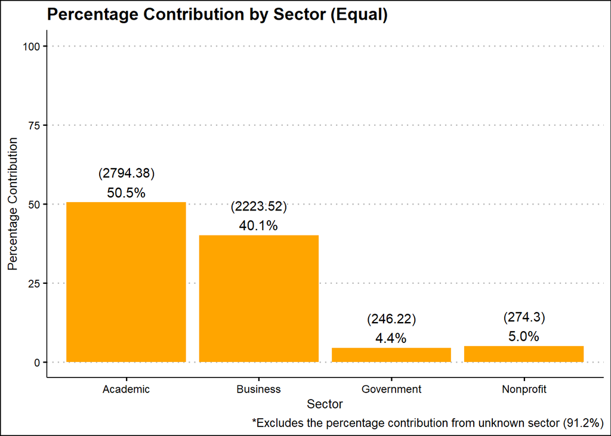

```r
### Excluding the unknown percentage in the table
total_excluding_unknown <- sum(sector_aggregated$overall_contribution_fraction[sector_aggregated$Sector != "Unknown"])

### recalculating what percentages would be without unknown
sector_aggregated <- sector_aggregated %>%
  mutate(percentage_contribution_excl_unknown = ifelse(Sector != "Unknown",
                                                       round((overall_contribution_fraction / total_excluding_unknown) * 100, 1), NA_real_))

### making labels
sector_aggregated$percentage_label_excl_unknown <- scales::percent(sector_aggregated$percentage_contribution_excl_unknown / 100, accuracy = 0.1)

ggplot(sector_aggregated %>% filter(Sector != "Unknown"), aes(x = Sector, y = percentage_contribution_excl_unknown)) +
  geom_bar(stat = "identity", fill = "orange") +
  geom_text(aes(label = percentage_label_excl_unknown), vjust = -0.5, size = 4) +
  geom_text(aes(label = paste0("(", round(overall_contribution_fraction, 2), ")")), position = position_dodge(width = 0.9), vjust = -2.5)+
  # Adjust vjust and size as needed
  labs(title = "Percentage Contribution by Sector (Equal)",
       x = "Sector",
       y = "Percentage Contribution") +
  theme_clean() +
  labs(caption = "*Excludes the percentage contribution from unknown sector (91.2%)")+
  ylim(0,100)
```

#### 2.1.1.2 How do we attribute contribution to sectors (weighted)?

We also can attribute contribution to sectors based on the lines of code written for a unique user of a given repository. The more lines of code added for that repository, the more credit that user will get. So, if a repository has 500 total lines of code, and one user wrote 300 of them, he/she would get .6 of the credit. We again apply the fractional counting method to the sectors after calculating this.

```r
# Calculate the total code additions for each slug (project/repository identifier)
# Grouping by the slug, and then summarizing the total additions for each slug.
slug_totals <- python_final %>%
  group_by(slug) %>%
  summarise(total_code_for_slug = sum(total_additions))

# Compute the contribution fraction for each user.
# This is done by joining the user's total additions with the total code additions for their respective slug,
# and then computing the user's contribution as a fraction of the slug's total.
python_final <- python_final %>%
  left_join(slug_totals, by = "slug") %>%
  mutate(contribution_fraction_loc = total_additions / total_code_for_slug)

# Compute the total contribution fraction for each combination of slug and sector.
# This groups the data by slug and sector, and then sums up the contribution fractions.
sector_addition_contribution <- python_final %>%
  group_by(slug, Sector) %>%
  summarise(total_addition_contribution = sum(contribution_fraction_loc))

# Aggregate the contributions at the sector level.
# This groups by the sector and then computes the overall contribution fraction for each sector.
sector_aggregated_additions <- sector_addition_contribution %>%
  group_by(Sector) %>%
  summarise(overall_addition_contribution = sum(total_addition_contribution, na.rm = TRUE))

# Compute the total overall additions across all sectors.
total_overall_additions = sum(sector_aggregated_additions$overall_addition_contribution)

# Calculate the percentage of additions for each sector relative to the total overall additions.
sector_aggregated_additions$percentage_additions = round((sector_aggregated_additions$overall_addition_contribution / total_overall_additions) * 100,1)

# Create a label for the percentage values, turning the decimal fraction into a percentage string (e.g., 0.5 becomes "50%").
sector_aggregated_additions$percentage_label_additions = scales::percent(sector_aggregated_additions$percentage_additions / 100)
```

After doing these calculations, we now see that 52% can be attributed to the academic sector, 39% to the business, 4% to the government, and 5% to the nonprofit. The original amount attributed to Unknown decreased to 90.6%

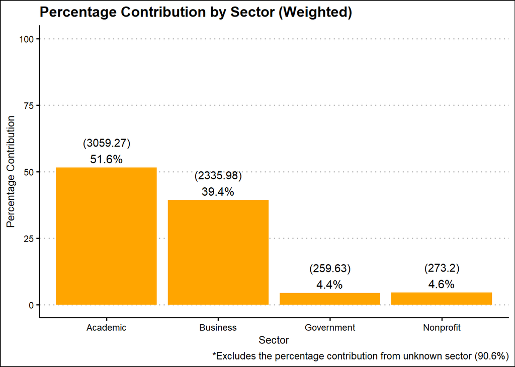

```r
# Calculate the total code additions while excluding the 'Unknown' sector.
total_excluding_unknown_add <- sum(sector_aggregated_additions$overall_addition_contribution[sector_aggregated_additions$Sector != "Unknown"])

# Compute the percentage contribution for each sector relative to the total (excluding 'Unknown' sector).
# If the sector is 'Unknown', set the percentage as NA.
sector_aggregated_additions <- sector_aggregated_additions %>%
  mutate(percentage_contribution_excl_unknown = ifelse(Sector != "Unknown",
                                                       round((overall_addition_contribution / total_excluding_unknown_add) * 100, 1), NA_real_))

# Create a label for the percentage values that excludes 'Unknown' sector, turning the decimal fraction into a percentage string.
sector_aggregated_additions$percentage_label_excl_unknown <- scales::percent(sector_aggregated_additions$percentage_contribution_excl_unknown / 100, accuracy = 0.1)

# Visualize data
ggplot(sector_aggregated_additions %>% filter(Sector != "Unknown"), aes(x = Sector, y = percentage_contribution_excl_unknown)) +
  geom_bar(stat = "identity", fill = "orange") +
  geom_text(aes(label = percentage_label_excl_unknown), vjust = -0.5, size = 4) +
  geom_text(aes(label = paste0("(", round(overall_addition_contribution, 2), ")")), position = position_dodge(width = 0.9), vjust = -2.5)+ # Adjust vjust and size as needed
  labs(title = "Percentage Contribution by Sector (Weighted)",
       x = "Sector",
       y = "Percentage Contribution") +
  theme_clean() +
  labs(caption = "*Excludes the percentage contribution from unknown sector (90.6%)")+
  ylim(0,100)
```

#### 2.1.1.3 Sectors Over time

```r
# Compute the total contribution fraction for each combination of slug, sector, and year
sector_addition_contribution <-python_final %>%
  group_by(slug, Sector, year_created) %>%
  summarise(total_addition_contribution = sum(contribution_fraction_loc), .groups = 'drop')

# Aggregate the contributions at the Sector and year level
sector_aggregated_additions <- sector_addition_contribution %>%
  group_by(Sector, year_created) %>%
  summarise(overall_addition_contribution = sum(total_addition_contribution, na.rm = TRUE), .groups = 'drop')

# Compute the total overall additions across all sectors by year
total_overall_additions_by_year <- sector_aggregated_additions %>%
  group_by(year_created) %>%
  summarise(yearly_total = sum(overall_addition_contribution), .groups = 'drop')

# Calculate the percentage of additions for each sector relative to the total overall additions for each year
sector_aggregated_additions <- sector_aggregated_additions %>%
  left_join(total_overall_additions_by_year, by = "year_created") %>%
  mutate(percentage_additions = (overall_addition_contribution / yearly_total) * 100)

# Calculate the total code additions for each year while excluding the 'Unknown' sector
total_excluding_unknown_by_year <- sector_aggregated_additions %>%
  filter(Sector != "Unknown") %>%
  group_by(year_created) %>%
  summarise(yearly_total_excl_unknown = sum(overall_addition_contribution), .groups = 'drop')

# Compute the percentage contribution for each sector by year relative to the year's total excluding 'Unknown'
sector_aggregated_additions <- sector_aggregated_additions %>%
  left_join(total_excluding_unknown_by_year, by = "year_created") %>%
  mutate(percentage_contribution_excl_unknown = ifelse(Sector != "Unknown" & !is.na(yearly_total_excl_unknown),
                                                       (overall_addition_contribution / yearly_total_excl_unknown) * 100,
                                                       NA_real_))

# Round the percentages and create labels
sector_aggregated_additions$percentage_contribution_excl_unknown <- round(sector_aggregated_additions$percentage_contribution_excl_unknown, 1)
sector_aggregated_additions$percentage_label_excl_unknown <- ifelse(is.na(sector_aggregated_additions$percentage_contribution_excl_unknown),
                                                                    NA_character_,
                                                                    percent(sector_aggregated_additions$percentage_contribution_excl_unknown / 100))

# Optional: Print the head of the final dataframe to check the results
print(head(sector_aggregated_additions))
```

```
# A tibble: 6 × 8
  Sector   year_created overall_addition_con…¹ yearly_total percentage_additions
  <chr>           <int>                  <dbl>        <dbl>                <dbl>
1 Academic         2008                0.00527           26               0.0203
2 Academic         2009                2.61             160               1.63
3 Academic         2010                5.41             378               1.43
4 Academic         2011               20.9              884               2.36
5 Academic         2012               35.4             1444               2.45
6 Academic         2013               61.4             2217               2.77
# ℹ abbreviated name: ¹overall_addition_contribution
# ℹ 3 more variables: yearly_total_excl_unknown <dbl>,
#   percentage_contribution_excl_unknown <dbl>,
#   percentage_label_excl_unknown <chr>
```

```r
sum(sector_aggregated_additions$overall_addition_contribution)
```

```
[1] 62984
```

```r
# Assuming sector_aggregated_additions contains the necessary processed data
# Filter out the 'Unknown' Sector for plotting
plot_data <- sector_aggregated_additions %>%
  filter(Sector != "Unknown",
         year_created != "NA" & year_created != "2023")
```

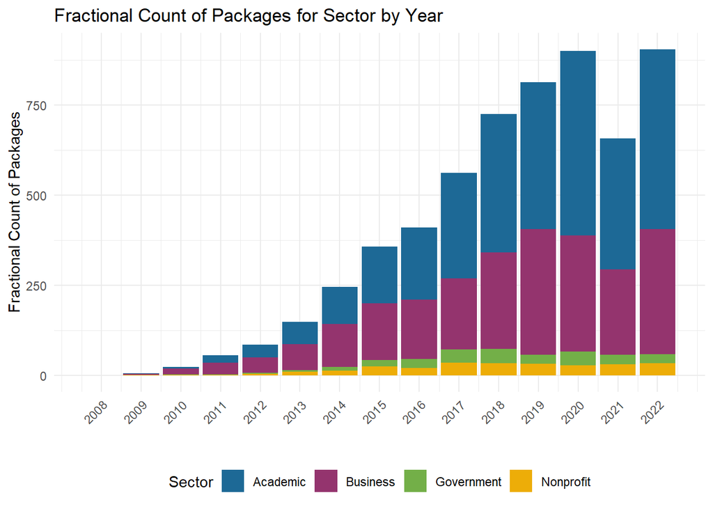

```r
# Stacked Bar Chart for Yearly Totals
Py_Sectors_time <- ggplot(plot_data, aes(x = year_created, y = overall_addition_contribution, fill = Sector)) +
  geom_bar(stat = "identity") +
  scale_fill_westat(option = "BLUES", drop = FALSE)+
   scale_x_continuous(breaks = seq(min(plot_data$year_created), max(plot_data$year_created))) +  # Ensure all years are shown
  labs(x = "", y = "Fractional Count of Packages", title = "Fractional Count of Packages for Sector by Year") + # Fractional Count of Packages for Sector by Year, y-axis: Fractional Count of Packages
  theme_minimal() +
  theme(axis.text.x = element_text(angle = 45, hjust = 1), legend.position = "bottom")

Py_Sectors_time
```

```r
ggsave(filename = "\\\\westat.com\\dfs\\DVSTAT\\Individual Directories\\Askew\\Paper_Data\\New Graphs\\Py_Sectors_time.png", plot = Py_Sectors_time, width = 8, height = 6, dpi = 300)
```

### 2.1.2 What is the distribution of GitHub Python contributors by country?

Based on the unique R GitHub users, the United States is the most frequent country found followed by Germany and the United Kingdom. Out of 184,444 unique users, there were 79,541 that we were unable to find a country for.

```r
### sum of Unknowns for country

sum(python_users_unique$country_fixed == "Unknown")
```

```
[1] 79541
```

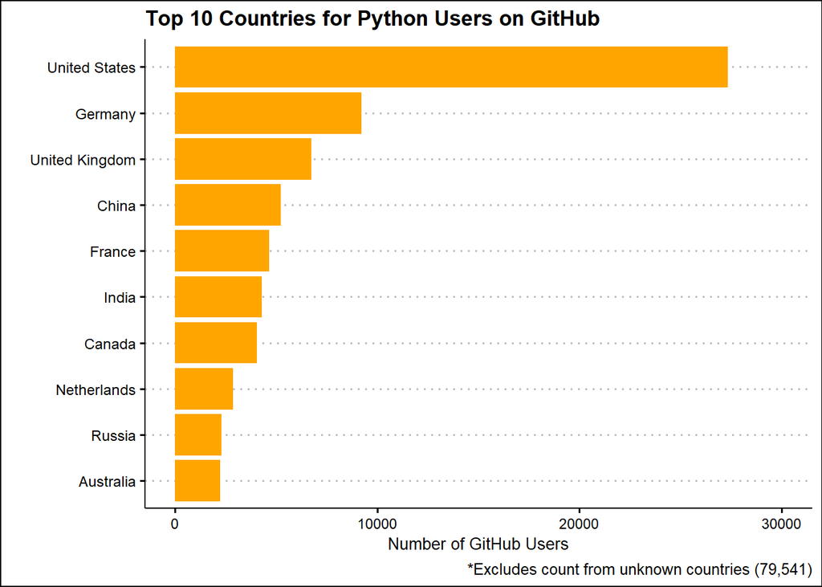

```r
### sorting to the top 10 most common countries for distinct GitHub users
top10_Countries_GitHub_users_unique <- python_users_unique %>%
  filter(country_fixed != "Unknown")

top10_Countries_GitHub_users_unique <-  sort(table(top10_Countries_GitHub_users_unique$country_fixed), decreasing = T)

top10_Countries_GitHub_users_unique  <- as.data.frame(head(top10_Countries_GitHub_users_unique , 10))

colnames(top10_Countries_GitHub_users_unique ) <- c("country_fixed", "Freq")

 ### Graph output of top 10 countries for unique maintainers
 ggplot(top10_Countries_GitHub_users_unique , aes(x = reorder(country_fixed, Freq), y = Freq))+
   geom_bar(stat = "identity", fill = "orange") +
    coord_flip() +
    scale_y_continuous(expand = c(0,0)) +
    labs(x = "", y = "Number of GitHub Users",
         title = "Top 10 Countries for Python Users on GitHub" ) +
    ylim(c(0, 30000))+
  theme_clean()+
   theme(
  plot.title = element_text(size = 13))+
   labs(caption = "*Excludes count from unknown countries (79,541)")
```

```r
### Table output of top 10 Institutions for packages
top10_Countries_GitHub_users_unique %>%
  kbl(caption = "Most Frequent Countries for Python Developers on GitHub", escape = F)%>%
  kable_classic()%>%
  kable_styling(font_size = 12, full_width = T)%>%
 row_spec(0, bold = T, background = westat_blue(), color = "white")%>%
  column_spec(1:2, border_right = T)%>%
  scroll_box()
```

Most Frequent Countries for Python Developers on GitHub

| country_fixed | Freq |
| --- | --- |
| United States | 27328 |
| Germany | 9213 |
| United Kingdom | 6736 |
| China | 5235 |
| France | 4653 |
| India | 4275 |
| Canada | 4038 |
| Netherlands | 2867 |
| Russia | 2286 |
| Australia | 2228 |

#### 2.1.2.1 How do we attribute contribution to countries (equal)?

For users that have multiple countries, we split the lines of code evenly between them in this code.

```r
# Function to handle the splitting and division for multiple countries
process_multiple_countries <- function(df) {
  num_countries <- length(str_split(df$country_fixed, ",\\s*")[[1]])
  df %>%
    separate_rows(country_fixed, sep = ",\\s*") %>%
    mutate(
      total_additions = total_additions / num_countries,
      contribution_fraction_equal = contribution_fraction_equal / num_countries,
      contribution_fraction_loc = contribution_fraction_loc / num_countries
    )
}


# Process rows with multiple countries
multi_country_rows <- python_final %>%
  filter(str_detect(country_fixed, ",")) %>%
  group_by(login) %>%
  do(process_multiple_countries(.))

# Exclude multi-country rows from the original df and bind the processed rows
python_final <- python_final %>%
  filter(!str_detect(country_fixed, ",")) %>%
  bind_rows(multi_country_rows)
```

```r
# Sum the contribution fraction for each sector per slug.
country_contribution <- python_final %>%
  group_by(slug, country_fixed) %>%
  summarise(total_contribution_fraction = sum(contribution_fraction_equal))

# Aggregate the contribution fraction for each country across all slugs
country_aggregated <- country_contribution %>%
  group_by(country_fixed) %>%
  summarise(overall_contribution_fraction = sum(total_contribution_fraction))

# Calculate the total overall contribution fraction over all countries
total_overall_contribution = sum(country_aggregated$overall_contribution_fraction)

# Calculate the percentage contribution for each country
country_aggregated = country_aggregated %>%
  mutate(percentage_contribution = round((overall_contribution_fraction / total_overall_contribution) * 100, 1))

### Plot percentage contribution
country_aggregated$percentage_label <- scales::percent(country_aggregated$percentage_contribution / 100)
```

If we give equal contributions to countries, then the United states would get 25% of the credit followed by Germany with 8.6% credit. This excludes the contribution counted towards unknown (45.9%), so these percentages are based on the percentage that we know (54.1%).

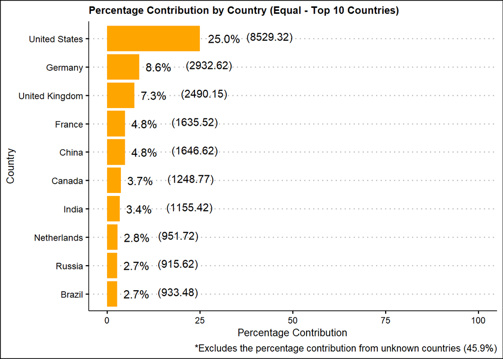

```r
total_excluding_unknown <- sum(country_aggregated$overall_contribution_fraction[country_aggregated$country_fixed != "Unknown"])

country_aggregated <- country_aggregated %>%
  mutate(percentage_contribution_excl_unknown = ifelse(country_fixed != "Unknown",
                                                       round((overall_contribution_fraction / total_excluding_unknown) * 100, 1), NA_real_))


country_aggregated$percentage_label_excl_unknown <- scales::percent(country_aggregated$percentage_contribution_excl_unknown / 100, accuracy = 0.1)


top_10_countries <- country_aggregated %>%
  arrange(desc(percentage_contribution_excl_unknown)) %>%
  head(10)

ggplot(top_10_countries, aes(x = reorder(country_fixed, percentage_contribution_excl_unknown),  y = percentage_contribution_excl_unknown)) +
  geom_bar(stat = "identity", fill = "orange") +
  geom_text(aes(label = percentage_label_excl_unknown), vjust = .5, size = 4, hjust = -.25) +
  geom_text(aes(label = paste0("(", round(overall_contribution_fraction, 2), ")")), position = position_dodge(width = 0.9), vjust = .25, hjust = -1)+# Adjust vjust and size as needed
  labs(title = "Percentage Contribution by Country (Equal - Top 10 Countries)",
       x = "Country",
       y = "Percentage Contribution") +
  theme_clean() +
  ylim(0,100)+
  coord_flip()+
  theme(plot.title = element_text(size = 10))+
  labs(caption = "*Excludes the percentage contribution from unknown countries (45.9%)")
```

#### 2.1.2.2 How do we attribute contribution to countries (weighted)?

```r
country_addition_contribution <- python_final %>%
  group_by(slug, country_fixed) %>%
  summarise(total_addition_contribution = sum(contribution_fraction_loc))

country_aggregated_additions <- country_addition_contribution %>%
  group_by(country_fixed) %>%
  summarise(overall_addition_contribution = sum(total_addition_contribution, na.rm = TRUE))

total_overall_additions = sum(country_aggregated_additions$overall_addition_contribution)

country_aggregated_additions$percentage_additions = round((country_aggregated_additions$overall_addition_contribution / total_overall_additions) * 100,1)

country_aggregated_additions$percentage_label_additions = scales::percent(country_aggregated_additions$percentage_additions / 100)
```

Based on additions, United states still is at the top, but it increases slightly to 26%. The top 10 changes slightly, with Japan jumping in and Russia jumping out.

```r
total_excluding_unknown <- sum(country_aggregated_additions$overall_addition_contribution[country_aggregated_additions$country_fixed != "Unknown"])

country_aggregated_additions <- country_aggregated_additions %>%
  mutate(percentage_contribution_excl_unknown = ifelse(country_fixed != "Unknown",
                                                       round((overall_addition_contribution / total_excluding_unknown) * 100, 1), NA_real_))


country_aggregated_additions$percentage_label_excl_unknown <- scales::percent(country_aggregated_additions$percentage_contribution_excl_unknown / 100, accuracy = 0.1)


top_10_countries_additions <- country_aggregated_additions %>%
  arrange(desc(percentage_contribution_excl_unknown)) %>%
  head(10)

 Py_country_weighted <- ggplot(top_10_countries_additions, aes(x = reorder(country_fixed, percentage_contribution_excl_unknown),  y = percentage_contribution_excl_unknown)) +
  geom_bar(stat = "identity", fill = "orange") +
  geom_text(aes(label = percentage_label_excl_unknown), vjust = .5, size = 6, hjust = -.12) +
  geom_text(aes(label = paste0("(", round(overall_addition_contribution, 2), ")")), position = position_dodge(width = 0.9), vjust = .5, hjust = -1.1, size = 5)+# Adjust vjust and size as needed
  theme_clean() +
  labs(x= "", y= "Percentage Contribution")+
  ylim(0,100)+
  coord_flip()+
  theme(axis.text = element_text(size = 14),
         axis.title = element_text(size = 12))



#ggsave("\\\\westat.com\\DFS\\DVSTAT\\Individual Directories\\Askew\\Py_country_weighted.png", plot = Py, width = 5, height = 5, dpi = 300)
```

#### 2.1.2.3 Countries over time

```r
# Step 1: Sum the contribution fraction for each country per slug, per year
country_contribution_by_year <- python_final %>%
  group_by(slug, country_fixed, year_created) %>%
  summarise(total_contribution_fraction = sum(contribution_fraction_loc, na.rm =  T), .groups = 'drop')

# Step 2: Aggregate the contribution fraction for each country by year
country_aggregated_by_year <- country_contribution_by_year %>%
  group_by(country_fixed, year_created) %>%
  summarise(overall_contribution_fraction = sum(total_contribution_fraction), .groups = 'drop')

# Step 3: Exclude 'Unknown' and determine the top ten countries for each year
country_aggregated_by_year_excl_unknown <- country_aggregated_by_year %>%
  filter(country_fixed != "Unknown")

# Step 4: Calculate the total overall contribution by year, excluding 'Unknown'
total_overall_contribution_by_year_excl_unknown <- country_aggregated_by_year_excl_unknown %>%
  group_by(year_created) %>%
  summarise(yearly_total_excl_unknown = sum(overall_contribution_fraction), .groups = 'drop')

# Now compute the percentage of contribution for each of the top countries, excluding 'Unknown'
country_aggregated_by_year_excl_unknown <- country_aggregated_by_year_excl_unknown %>%
  left_join(total_overall_contribution_by_year_excl_unknown, by = "year_created") %>%
  mutate(percentage_contribution_excl_unknown = (overall_contribution_fraction / yearly_total_excl_unknown) * 100) %>%
  arrange(year_created, desc(percentage_contribution_excl_unknown))

# Step 5: Get the top ten countries by year, excluding 'Unknown'
top_countries_by_year_excl_unknown <- country_aggregated_by_year_excl_unknown %>%
  group_by(year_created) %>%
  top_n(10, wt = percentage_contribution_excl_unknown) %>%
  ungroup()

# Filter out the 'Unknown' sector for plotting
plot_data2 <- top_countries_by_year_excl_unknown %>%
  filter(year_created != "NA" & year_created != "2023")


sum(country_aggregated_by_year$overall_contribution_fraction)
```

```
[1] 62984
```

```r
plot_data3 <- top_countries_by_year_excl_unknown %>%
  filter(year_created != "NA" & year_created != "2023",
         country_fixed %in% c("United States", "Germany", "United Kingdom", "France", "China", "Canada", "India", "Netherlands", "Russia", "Brazil"))
```

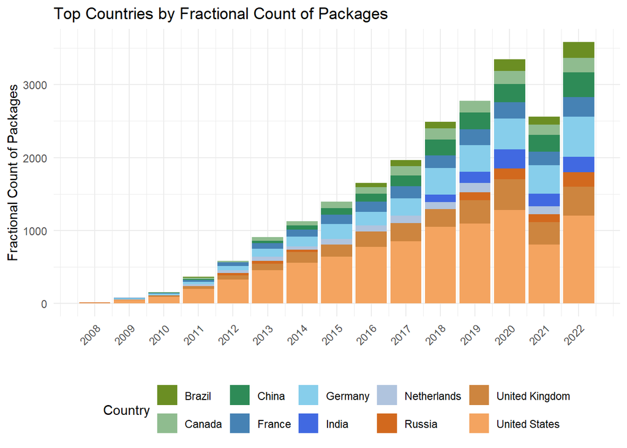

```r
my_colors <- c("#6B8E23", "#8FBC8F", "#2E8B57", "#4682B4", "#87CEEB",
               "#4169E1", "#B0C4DE", "#D2691E", "#CD853F", "#F4A460")


# Stacked Bar Chart for Yearly Totals
Py_Country_time <- ggplot(plot_data3, aes(x = year_created, y = overall_contribution_fraction, fill = country_fixed)) +
  geom_bar(stat = "identity") +
  scale_fill_manual(values = my_colors) +
  scale_x_continuous(breaks = seq(min(plot_data$year_created), max(plot_data$year_created), by = 1)) +
  labs(x = "", y = "Fractional Count of Packages", title = "Top Countries by Fractional Count of Packages", fill = "Country") + # Top Countries by Fractional Count of Packages, y-axis: Fractional Count of Packages
  theme_minimal() +
  theme(axis.text.x = element_text(angle = 45, hjust = 1), legend.position = "bottom")

Py_Country_time
```

```r
ggsave(filename = "\\\\westat.com\\dfs\\DVSTAT\\Individual Directories\\Askew\\Paper_Data\\New Graphs\\Py_Country_time.png", plot = Py_Country_time, width = 8, height = 6, dpi = 300)
```

### 2.1.3 What is the distribution of unique GitHub Python contributors by organization?

We also have the organization/institution variable for some users. It works with the sector variable, so if we were not able to identify a sector, we also were not able to identify an organization.

If we look at the top 10 most frequent organizations for unique R developers on Github, Google has the most with 1,994 followed by NetEase with 878. Only one in the top 10 is from a sector other than business (University of California-Berkeley - Academic)

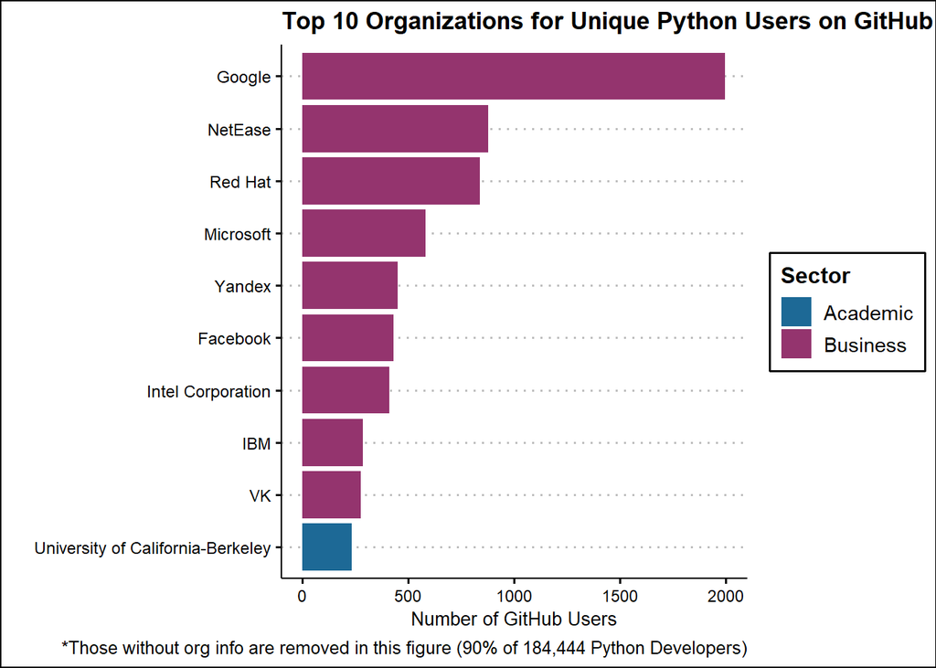

```r
### filter out Unknown
top10_Institutions_GitHub_users_unique <- python_users_unique %>%
                                              filter(Institution != "Unknown")

### sorting to the top 10 most common institutions for distinct GitHub users
top10_Institutions_GitHub_users_unique <- sort(table(top10_Institutions_GitHub_users_unique$Institution), decreasing = T)
top10_Institutions_GitHub_users_unique <- as.data.frame(head(top10_Institutions_GitHub_users_unique, 10))

colnames(top10_Institutions_GitHub_users_unique) <- c("Institution", "Freq")

### joining to institution unique dataframe to get sector variable
top10_Institutions_GitHub_users_unique <- python_users_unique %>%
  right_join(top10_Institutions_GitHub_users_unique, by = "Institution")%>%
  distinct(Institution, .keep_all = T)%>%
  select(Institution, Sector, Freq)%>%
  arrange(desc(Freq))

 ### Graph output of top 10 institutions for unique maintainers
 ggplot(top10_Institutions_GitHub_users_unique, aes(x = reorder(Institution, Freq), y = Freq, fill = Sector))+
   geom_bar(stat = "identity") +
    coord_flip() +
    scale_y_continuous(expand = c(0,0)) +
    labs(x = "", y = "Number of GitHub Users",
         title = "Top 10 Organizations for Unique Python Users on GitHub" ) +
    ylim(c(0, 2000))+
  scale_fill_westat(option = "BLUES", drop = FALSE)+
  theme_clean()+
   theme(
  plot.title = element_text(size = 13))+
   labs(caption = "*Those without org info are removed in this figure (90% of 184,444 Python Developers)")
```

```r
### Table output of top 10 Institutions for packages
top10_Institutions_GitHub_users_unique %>%
  kbl(caption = "Most Frequent Institutions for Python Developers on GitHub", escape = F)%>%
  kable_classic()%>%
  kable_styling(font_size = 12, full_width = T)%>%
 row_spec(0, bold = T, background = westat_blue(), color = "white")%>%
  column_spec(1:2, border_right = T)%>%
  scroll_box()
```

Most Frequent Institutions for Python Developers on GitHub

| Institution | Sector | Freq |
| --- | --- | --- |
| Google | Business | 1994 |
| NetEase | Business | 878 |
| Red Hat | Business | 837 |
| Microsoft | Business | 582 |
| Yandex | Business | 451 |
| Facebook | Business | 429 |
| Intel Corporation | Business | 409 |
| IBM | Business | 284 |
| VK | Business | 275 |
| University of California-Berkeley | Academic | 234 |

#### 2.1.3.1 How do we attribute contribution to organization (equal)?

```r
# Sum the contribution fraction for each organization per slug.
org_contribution <- python_final %>%
  group_by(slug, Institution) %>%
  summarise(total_contribution_fraction = sum(contribution_fraction_equal))

# Aggregate the contribution fraction for Institution across all slugs
org_aggregated <- org_contribution %>%
  group_by(Institution) %>%
  summarise(overall_contribution_fraction = sum(total_contribution_fraction))

# Calculate the total overall contribution fraction over all Institutions
total_overall_contribution = sum(org_aggregated$overall_contribution_fraction)

# Calculate the percentage contribution for each Institution
org_aggregated = org_aggregated %>%
  mutate(percentage_contribution = round((overall_contribution_fraction / total_overall_contribution) * 100, 1))

### Plot percentage contribution
org_aggregated$percentage_label <- scales::percent(org_aggregated$percentage_contribution / 100)
```

Again, the equal percentage contribution to Unknown is 91.2% just like we saw in the sector contribution section. Of the percentage we do know, NetEase leads with 5.6% followed by Google with 5.4%

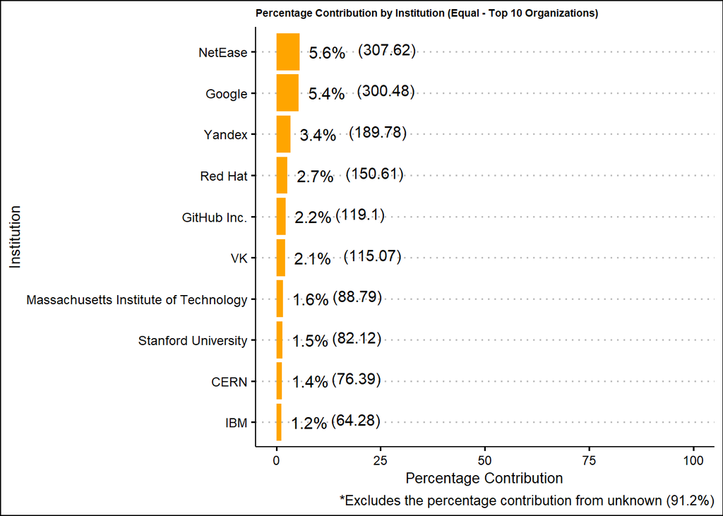

```r
total_excluding_unknown <- sum(org_aggregated$overall_contribution_fraction[org_aggregated$Institution != "Unknown"])

org_aggregated <- org_aggregated %>%
  mutate(percentage_contribution_excl_unknown = ifelse(Institution != "Unknown",
                                                       round((overall_contribution_fraction / total_excluding_unknown) * 100, 1), NA_real_))


org_aggregated$percentage_label_excl_unknown <- scales::percent(org_aggregated$percentage_contribution_excl_unknown / 100, accuracy = 0.1)


top_10_orgs <- org_aggregated %>%
  arrange(desc(percentage_contribution_excl_unknown)) %>%
  head(10)

ggplot(top_10_orgs, aes(x = reorder(Institution, percentage_contribution_excl_unknown),  y = percentage_contribution_excl_unknown)) +
  geom_bar(stat = "identity", fill = "orange") +
  geom_text(aes(label = percentage_label_excl_unknown), vjust = .5, size = 4, hjust = -.25) +
  geom_text(aes(label = paste0("(", round(overall_contribution_fraction, 2), ")")), position = position_dodge(width = 0.9), vjust = .25, hjust = -1)+# Adjust vjust and size as needed
  labs(title = "Percentage Contribution by Institution (Equal - Top 10 Organizations)",
       x = "Institution",
       y = "Percentage Contribution") +
  theme_clean() +
  ylim(0,100)+
  coord_flip()+
  theme(plot.title = element_text(size = 7))+
  labs(caption = "*Excludes the percentage contribution from unknown (91.2%)")
```

#### 2.1.3.2 How do we attribute contribution to organizations (weighted)?

```r
org_addition_contribution <- python_final %>%
  group_by(slug, Institution) %>%
  summarise(total_addition_contribution = sum(contribution_fraction_loc))

org_aggregated_additions <- org_addition_contribution %>%
  group_by(Institution) %>%
  summarise(overall_addition_contribution = sum(total_addition_contribution, na.rm = TRUE))

total_overall_additions = sum(org_aggregated_additions$overall_addition_contribution)

org_aggregated_additions$percentage_additions = round((org_aggregated_additions$overall_addition_contribution / total_overall_additions) * 100,1)

org_aggregated_additions$percentage_label_additions = scales::percent(org_aggregated_additions$percentage_additions / 100)
```

Based on additions, the percentage contribution towards unknown is 90.6% just as we saw for sector, which is what we expect because the two variables coincide with one another. The percentage coming from NetEase decreases to 5.2% (now number two), and Google jumps to first with 5.9%

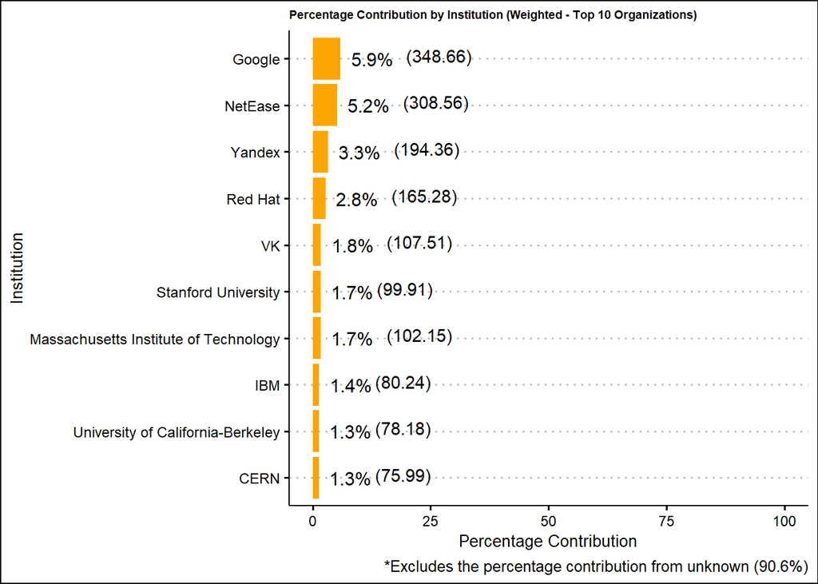

```r
total_excluding_unknown <- sum(org_aggregated_additions$overall_addition_contribution[org_aggregated_additions$Institution != "Unknown"])

org_aggregated_additions <- org_aggregated_additions %>%
  mutate(percentage_contribution_excl_unknown = ifelse(Institution != "Unknown",
                                                       round((overall_addition_contribution / total_excluding_unknown) * 100, 1), NA_real_))


org_aggregated_additions$percentage_label_excl_unknown <- scales::percent(org_aggregated_additions$percentage_contribution_excl_unknown / 100, accuracy = 0.1)


top_10_orgs_additions <- org_aggregated_additions %>%
  arrange(desc(percentage_contribution_excl_unknown)) %>%
  head(10)

ggplot(top_10_orgs_additions, aes(x = reorder(Institution, percentage_contribution_excl_unknown),  y = percentage_contribution_excl_unknown)) +
  geom_bar(stat = "identity", fill = "orange") +
  geom_text(aes(label = percentage_label_excl_unknown), vjust = .5, size = 4, hjust = -.25) +
  geom_text(aes(label = paste0("(", round(overall_addition_contribution, 2), ")")), position = position_dodge(width = 0.9), vjust = .25, hjust = -1)+# Adjust vjust and size as needed
  labs(title = "Percentage Contribution by Institution (Weighted - Top 10 Organizations)",
       x = "Institution",
       y = "Percentage Contribution") +
  theme_clean() +
  ylim(0,100)+
  coord_flip()+
  theme(plot.title = element_text(size = 7))+
  labs(caption = "*Excludes the percentage contribution from unknown (90.6%)")
```

## 2.2 Network Analysis

- What are the overall structural features of the OSS networks? How do they differ across fields, sectors, institutions, and countries? Units of analysis (OSS actors): projects, categories, developers, institutions, sectors, countries
- What are the different communities that can be identified using structural features of the networks? Do they correspond to similarities in languages, methods, location, culture?

### 2.2.1 Countries

```r
### select dependency information for slugs and packages
py_github_rdi <- python_final %>%
                    distinct(Package, .keep_all = T) %>%
                      select(Package, slug, dependencies)

### rename columns
colnames(py_github_rdi) <- c("Citing_Package", "slug", "Dependencies")


### Package citation column will be the unlisted dependencies column
py_github_rdi$Package_Citation <- py_github_rdi$Dependencies


### join commits information for the citing packages
py_github_RDI <- py_github_rdi %>%
                      inner_join(python_final, by = "slug")%>%
                        select(Citing_Package, slug, Dependencies, login,
                             country_fixed, total_additions, total_code_for_slug,
                             contribution_fraction_loc, Package_Citation) %>%
                       # Remove rows with NA in Depends
                        filter(Package_Citation != "")

### rename columns on the basis of the citing package
colnames(py_github_RDI) <- c("Citing_Package", "Citing_Slug", "Dependencies", "Citing_Login",  "Citing_Country",
                                "Citing_Additions", "Citing_Total_Slug_Additions", "Citing_Package_Fraction" , "Package_Citation")


### unlist the dependencies for joining
py_github_RDI_network <-  py_github_RDI %>%
  separate_rows(Package_Citation, sep = ",\\s*") %>%
  filter(Package_Citation != "")


#### prepare commits information for cited packages
python_final_rdi <- python_final %>%
  mutate(Package_Citation = str_split(slug, "/", simplify = TRUE)[, 2])%>%
  select(login, country_fixed, total_additions, total_code_for_slug, contribution_fraction_loc, Package_Citation)

  colnames(python_final_rdi) <- c( "Cited_Login", "Cited_Country",
                                   "Cited_Additions", "Cited_Total_Slug_Additions", "Cited_Package_Fraction", "Package_Citation")


# Function to split a dataframe into chunks based on unique values of a specified column
split_data_into_chunks <- function(data, column_name) {
  # Ensure that the column exists in the dataframe
  if (!column_name %in% names(data)) {
    stop("Column not found in the dataframe.")
  }

  # Split the dataframe into a list of dataframes, each for a unique value of the specified column
  chunks <- split(data, data[[column_name]])

  return(chunks)
}

# Assuming 'df' and 'python_final_rdi' are already defined dataframes
# Replace 'df' with the actual dataframe variable name
chunks <- split_data_into_chunks(py_github_RDI_network, "Citing_Package")

# Function to process each chunk
process_chunk <- function(chunk) {
  chunk %>%
    inner_join(python_final_rdi, by = "Package_Citation") %>%
    mutate(Dependency_Fraction = Citing_Package_Fraction * Cited_Package_Fraction) %>%
    group_by(Cited_Country, Citing_Country) %>%
    summarize(Total_Dependency_Fraction = round(sum(Dependency_Fraction, na.rm = TRUE), 4), .groups = "drop") # Ensure the result is ungrouped for later binding
}

# Process each chunk and store the results
results <- lapply(chunks, process_chunk)

# Combine results into a single dataframe
dependency_summary  <- bind_rows(results) %>%
  group_by(Cited_Country, Citing_Country) %>%
  summarize(Total_Dependency_Fraction = sum(Total_Dependency_Fraction, na.rm = TRUE)) %>%
  ungroup()
```

```r
dependency_summary <- read.csv("\\\\westat.com\\DFS\\DVSTAT\\Individual Directories\\Askew\\Paper_Data\\PyPi_EdgeList.csv")
```

```r
# Group by Cited Country and Citing Country, and sum Dependency_Fraction

### the number of citations made from one country to another is simply the sum of the fractioned scores associated with each pair, with the sum across all possible pairs adding up to the total number of citations made at the world level.

sum(dependency_summary$Total_Dependency_Fraction)
```

```
[1] 72705.38
```

```r
# Group by Cited Country and sum Total_Dependency_Fraction - total number of citations attributed to each country
citations_by_country <- dependency_summary %>%
  group_by(Cited_Country) %>%
  summarize(Fraction_of_Citations = sum(Total_Dependency_Fraction, na.rm = TRUE))


sum(citations_by_country$Fraction_of_Citations)
```

```
[1] 72705.38
```

```r
citations_by_country$Denominator_RDI <- round(citations_by_country$Fraction_of_Citations / sum(citations_by_country$Fraction_of_Citations),4)

# Group by citing country and sum Total_Dependency_Fraction - total number of citations made by each country
citings_by_country <- dependency_summary %>%
  group_by(Citing_Country) %>%
  summarize(Fraction_of_Citings = round(sum(Total_Dependency_Fraction, na.rm = TRUE), 4))


sum(citings_by_country$Fraction_of_Citings)
```

```
[1] 72705.38
```

```r
# join citings by country with dependency_summary

citings_dependency_summary <- citings_by_country %>%
                                full_join(dependency_summary, by = "Citing_Country")

citings_dependency_summary$Numerator_RDI <- round(citings_dependency_summary$Total_Dependency_Fraction / citings_dependency_summary$Fraction_of_Citings,4)

## join denominator_RDI

citations_citings_dependency_summary <- citations_by_country %>%
                                full_join(citings_dependency_summary, by = "Cited_Country") %>%
                                select(Citing_Country, Cited_Country, Numerator_RDI, Denominator_RDI)

citations_citings_dependency_summary$RDI <- citations_citings_dependency_summary$Numerator_RDI / citations_citings_dependency_summary$Denominator_RDI
```

```r
dependency_summary %>%
  arrange(desc(Total_Dependency_Fraction))%>%
   slice_max(order_by = Total_Dependency_Fraction, n = 50) %>%
  kbl(caption = "Country Pair Dependency Weights", escape = F)%>%
  kable_classic()%>%
  kable_styling(font_size = 12, full_width = T)%>%
 row_spec(0, bold = T, background = westat_blue(), color = "white")%>%
  column_spec(1:2, border_right = T)%>%
  scroll_box(width = "100%", height = "500px")
```

Country Pair Dependency Weights

| Cited_Country | Citing_Country | Total_Dependency_Fraction |
| --- | --- | --- |
| Unknown | Unknown | 10604.7854 |
| United States | Unknown | 6083.2040 |
| Unknown | United States | 4122.2103 |
| United States | United States | 2919.3771 |
| United Kingdom | Unknown | 2492.9614 |
| Germany | Unknown | 1932.2912 |
| Unknown | Germany | 1625.6417 |
| Unknown | United Kingdom | 1227.4102 |
| United States | Germany | 944.7226 |
| United Kingdom | United States | 915.7121 |
| Japan | Unknown | 836.9328 |
| Brazil | Unknown | 824.2033 |
| Germany | United States | 816.8986 |
| Unknown | France | 722.1529 |
| United States | United Kingdom | 694.1696 |
| Austria | Unknown | 670.1900 |
| France | Unknown | 606.1713 |
| Unknown | Canada | 568.2824 |
| Finland | Unknown | 547.9187 |
| Unknown | China | 539.1591 |
| Netherlands | Unknown | 520.4825 |
| Germany | Germany | 490.0547 |
| Unknown | India | 463.9618 |
| Unknown | Switzerland | 460.9041 |
| Canada | Unknown | 460.0580 |
| Unknown | Netherlands | 459.1805 |
| United States | France | 433.3521 |
| Romania | Unknown | 420.1962 |
| Brazil | United States | 392.3759 |
| United Kingdom | Germany | 374.8262 |
| United Kingdom | United Kingdom | 374.4806 |
| Japan | United States | 348.9630 |
| United States | China | 342.9853 |
| United States | Canada | 323.3553 |
| Austria | United States | 310.6929 |
| Unknown | Russia | 304.6393 |
| Unknown | Australia | 303.7654 |
| Unknown | Japan | 300.9108 |
| Unknown | Brazil | 297.9320 |
| United States | Netherlands | 290.5260 |
| United States | Switzerland | 266.7036 |
| Germany | United Kingdom | 252.8603 |
| Unknown | Spain | 251.4286 |
| United States | India | 236.9772 |
| Romania | United States | 226.7484 |
| France | United States | 226.3129 |
| Belgium | Unknown | 220.5093 |
| Unknown | Italy | 216.4867 |
| Australia | Unknown | 205.8331 |
| Spain | Unknown | 202.8082 |

### 2.2.2 Sectors

```r
### select dependency information for slugs and packages
py_github_rdi <- python_final %>%
                    distinct(Package, .keep_all = T) %>%
                      select(Package, slug, dependencies)

### rename columns
colnames(py_github_rdi) <- c("Citing_Package", "slug", "Dependencies")


### Package citation column will be the unlisted dependencies column
py_github_rdi$Package_Citation <- py_github_rdi$Dependencies


### join commits information for the citing packages
py_github_RDI <- py_github_rdi %>%
                      inner_join(python_final, by = "slug")%>%
                        select(Citing_Package, slug, Dependencies, login,
                             Sector, total_additions, total_code_for_slug,
                             contribution_fraction_loc, Package_Citation) %>%
                       # Remove rows with NA in Depends
                        filter(Package_Citation != "")

### rename columns on the basis of the citing package
colnames(py_github_RDI) <- c("Citing_Package", "Citing_Slug", "Dependencies", "Citing_Login",  "Citing_Sector",
                                "Citing_Additions", "Citing_Total_Slug_Additions", "Citing_Package_Fraction" , "Package_Citation")


### unlist the dependencies for joining
py_github_RDI_network <-  py_github_RDI %>%
  separate_rows(Package_Citation, sep = ",\\s*") %>%
  filter(Package_Citation != "")


#### prepare commits information for cited packages
python_final_rdi <- python_final %>%
  mutate(Package_Citation = str_split(slug, "/", simplify = TRUE)[, 2])%>%
  select(login, Sector, total_additions, total_code_for_slug, contribution_fraction_loc, Package_Citation)

  colnames(python_final_rdi) <- c( "Cited_Login", "Cited_Sector",
                                   "Cited_Additions", "Cited_Total_Slug_Additions", "Cited_Package_Fraction", "Package_Citation")


# Function to split a dataframe into chunks based on unique values of a specified column
split_data_into_chunks <- function(data, column_name) {
  # Ensure that the column exists in the dataframe
  if (!column_name %in% names(data)) {
    stop("Column not found in the dataframe.")
  }

  # Split the dataframe into a list of dataframes, each for a unique value of the specified column
  chunks <- split(data, data[[column_name]])

  return(chunks)
}

# Assuming 'df' and 'python_final_rdi' are already defined dataframes
# Replace 'df' with the actual dataframe variable name
chunks <- split_data_into_chunks(py_github_RDI_network, "Citing_Package")

# Function to process each chunk
process_chunk <- function(chunk) {
  chunk %>%
    inner_join(python_final_rdi, by = "Package_Citation") %>%
    mutate(Dependency_Fraction = Citing_Package_Fraction * Cited_Package_Fraction) %>%
    group_by(Cited_Sector, Citing_Sector) %>%
    summarize(Total_Dependency_Fraction = round(sum(Dependency_Fraction, na.rm = TRUE), 4), .groups = "drop") # Ensure the result is ungrouped for later binding
}

# Process each chunk and store the results
results <- lapply(chunks, process_chunk)

# Combine results into a single dataframe
dependency_summary  <- bind_rows(results) %>%
  group_by(Cited_Sector, Citing_Sector) %>%
  summarize(Total_Dependency_Fraction = sum(Total_Dependency_Fraction, na.rm = TRUE)) %>%
  ungroup()
```

```r
 write.csv(dependency_summary,"\\\\westat.com\\DFS\\DVSTAT\\Individual Directories\\Askew\\Paper_Data\\PyPi_Sector_EdgeList.csv", row.names = F)
```

### 2.2.3 Orgs

```r
### select dependency information for slugs and packages
py_github_rdi <- python_final %>%
                    distinct(Package, .keep_all = T) %>%
                      select(Package, slug, dependencies)

### rename columns
colnames(py_github_rdi) <- c("Citing_Package", "slug", "Dependencies")


### Package citation column will be the unlisted dependencies column
py_github_rdi$Package_Citation <- py_github_rdi$Dependencies


### join commits information for the citing packages
py_github_RDI <- py_github_rdi %>%
                      inner_join(python_final, by = "slug")%>%
                        select(Citing_Package, slug, Dependencies, login,
                             Institution, total_additions, total_code_for_slug,
                             contribution_fraction_loc, Package_Citation) %>%
                       # Remove rows with NA in Depends
                        filter(Package_Citation != "")

### rename columns on the basis of the citing package
colnames(py_github_RDI) <- c("Citing_Package", "Citing_Slug", "Dependencies", "Citing_Login",  "Citing_Org",
                                "Citing_Additions", "Citing_Total_Slug_Additions", "Citing_Package_Fraction" , "Package_Citation")


### unlist the dependencies for joining
py_github_RDI_network <-  py_github_RDI %>%
  separate_rows(Package_Citation, sep = ",\\s*") %>%
  filter(Package_Citation != "")


#### prepare commits information for cited packages
python_final_rdi <- python_final %>%
  mutate(Package_Citation = str_split(slug, "/", simplify = TRUE)[, 2])%>%
  select(login, Institution, total_additions, total_code_for_slug, contribution_fraction_loc, Package_Citation)

  colnames(python_final_rdi) <- c( "Cited_Login", "Cited_Org",
                                   "Cited_Additions", "Cited_Total_Slug_Additions", "Cited_Package_Fraction", "Package_Citation")


# Function to split a dataframe into chunks based on unique values of a specified column
split_data_into_chunks <- function(data, column_name) {
  # Ensure that the column exists in the dataframe
  if (!column_name %in% names(data)) {
    stop("Column not found in the dataframe.")
  }

  # Split the dataframe into a list of dataframes, each for a unique value of the specified column
  chunks <- split(data, data[[column_name]])

  return(chunks)
}

# Assuming 'df' and 'python_final_rdi' are already defined dataframes
# Replace 'df' with the actual dataframe variable name
chunks <- split_data_into_chunks(py_github_RDI_network, "Citing_Package")

# Function to process each chunk
process_chunk <- function(chunk) {
  chunk %>%
    inner_join(python_final_rdi, by = "Package_Citation") %>%
    mutate(Dependency_Fraction = Citing_Package_Fraction * Cited_Package_Fraction) %>%
    group_by(Cited_Org, Citing_Org) %>%
    summarize(Total_Dependency_Fraction = round(sum(Dependency_Fraction, na.rm = TRUE), 4), .groups = "drop") # Ensure the result is ungrouped for later binding
}

# Process each chunk and store the results
results <- lapply(chunks, process_chunk)

# Combine results into a single dataframe
dependency_summary  <- bind_rows(results) %>%
  group_by(Cited_Org, Citing_Org) %>%
  summarize(Total_Dependency_Fraction = sum(Total_Dependency_Fraction, na.rm = TRUE)) %>%
  ungroup()
```

### 2.2.4 Double-sided bar graph

```r
# Calculate the total of Fraction_of_Citations, including "Unknown"
total_citations_incl_unknown <- sum(citations_by_country$Fraction_of_Citations)

# Create and round the percentage column to the nearest hundredth, including "Unknown" in the percentage calculation
citations_by_country$Percentage_of_Citations <- round(
  (citations_by_country$Fraction_of_Citations / total_citations_incl_unknown) * 100, 2
)

# Arrange by descending order of the new percentage column
 citations_by_country %>%
  arrange(desc(Percentage_of_Citations))
```

```
# A tibble: 184 × 4
   Cited_Country  Fraction_of_Citations Denominator_RDI Percentage_of_Citations
   <chr>                          <dbl>           <dbl>                   <dbl>
 1 Unknown                       25571.          0.352                    35.2
 2 United States                 15471.          0.213                    21.3
 3 United Kingdom                 6101.          0.0839                    8.39
 4 Germany                        5086.          0.07                      7
 5 Brazil                         2180.          0.03                      3
 6 Japan                          2178.          0.03                      3
 7 Austria                        1782.          0.0245                    2.45
 8 France                         1541.          0.0212                    2.12
 9 Finland                        1270.          0.0175                    1.75
10 Netherlands                    1216.          0.0167                    1.67
# ℹ 174 more rows
```

```r
# Calculate the total of Fraction_of_Citations, excluding "Unknown"
total_citations <- sum(citations_by_country$Fraction_of_Citations[citations_by_country$Cited_Country != "Unknown"])

# Create and round the percentage column to the nearest hundredth, excluding "Unknown" in the percentage calculation
citations_by_country$Percentage_of_Citations <- ifelse(
  citations_by_country$Cited_Country == "Unknown",
  NA,
  round((citations_by_country$Fraction_of_Citations / total_citations) * 100, 2)
)



citations_by_country %>%
  arrange(desc(Percentage_of_Citations))
```

```
# A tibble: 184 × 4
   Cited_Country  Fraction_of_Citations Denominator_RDI Percentage_of_Citations
   <chr>                          <dbl>           <dbl>                   <dbl>
 1 United States                 15471.          0.213                    32.8
 2 United Kingdom                 6101.          0.0839                   12.9
 3 Germany                        5086.          0.07                     10.8
 4 Brazil                         2180.          0.03                      4.63
 5 Japan                          2178.          0.03                      4.62
 6 Austria                        1782.          0.0245                    3.78
 7 France                         1541.          0.0212                    3.27
 8 Finland                        1270.          0.0175                    2.7
 9 Netherlands                    1216.          0.0167                    2.58
10 Romania                        1206.          0.0166                    2.56
# ℹ 174 more rows
```

The following graph shows a countries’ lines of code credit compared to the percentage of citations they have from other countries (or reverse dependencies in package language)

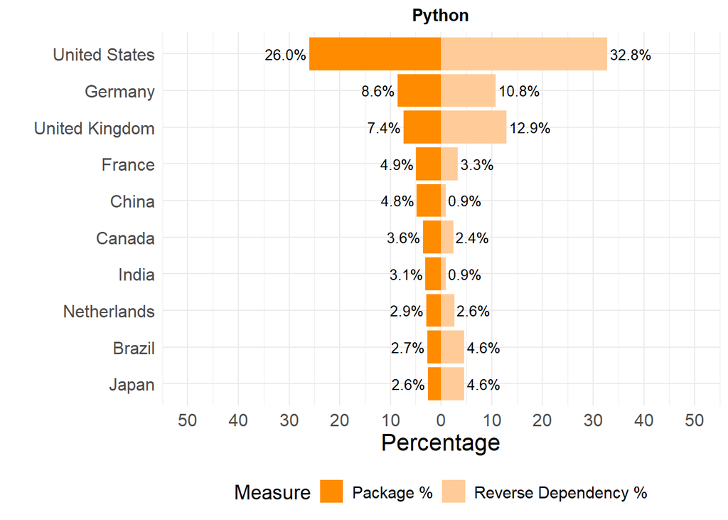

```r
data <- data.frame(
  Country = c("United States", "Germany", "United Kingdom", "France", "China",
              "Canada", "India", "Netherlands", "Brazil", "Japan",
              "United States", "Germany", "United Kingdom", "France", "China",
              "Canada", "India", "Netherlands", "Brazil", "Japan"),
  Measure = c("Reverse Dependency %", "Reverse Dependency %", "Reverse Dependency %", "Reverse Dependency %", "Reverse Dependency %",
              "Reverse Dependency %", "Reverse Dependency %", "Reverse Dependency %", "Reverse Dependency %", "Reverse Dependency %",
              "Package %", "Package %", "Package %", "Package %", "Package %",
              "Package %", "Package %", "Package %", "Package %", "Package %"),
  Value = c(32.8, 10.8, 12.9, 3.3, .9, 2.4, .9, 2.6, 4.6, 4.6,
            -26, -8.6, -7.4, -4.9, -4.8,  -3.6, -3.1, -2.9, -2.7, -2.6) # Negative for Dependency %, positive for Code%
)

# Filter data to include only Code % values for ordering
code_values <- data %>%
  filter(Measure == "Package %") %>%
  arrange(desc(Value))

# Reorder Country factor based on Code % values
data$Country <- factor(data$Country, levels = code_values$Country)

plot <- ggplot(data, aes(x = Country, y = Value, fill = Measure)) +
  geom_bar(stat = "identity", position = "identity") +# Size of the text, can be adjusted as needed
  coord_flip() +
  scale_y_continuous(labels = abs, breaks = seq(-50, 50, by = 10), limits = c(-50, 50)) +
  labs(y = "Percentage", x = "", title = "Python") +
  theme_minimal() +
  scale_fill_manual(values = c("Package %" = "darkorange", "Reverse Dependency %" = "#FFCC99")) + # Add your own colors
  theme(
    text = element_text(size = 14),
    axis.title = element_text(size = 16),
    axis.text = element_text(size = 12),
    plot.title = element_text(size = 12, face = "bold", hjust = .5)
  ) +
  geom_text(data = subset(data, Value > 0), aes(label = sprintf("%0.1f%%", Value)),
            position = position_nudge(y = 0.5), hjust = 0, size = 3.5) +
  geom_text(data = subset(data, Value < 0), aes(label = sprintf("%0.1f%%", abs(Value))),
            position = position_nudge(y = -0.5), hjust = 1, size = 3.5)+
  theme(legend.position = "bottom")

plot
```

The following code is some analysis for a working paper… results are not commented on at the moment, but we want to see if larger teams have more impact on average.

## 2.3 How does team size relate to impact?

```r
## Create team size
python_final <- python_final %>%
  group_by(slug) %>%
  mutate(team_size = n()) %>%
  ungroup()

python_final <- python_final %>%
                              left_join(python_revdep, by = "Package")

## normalize stars and forks based on year_created

python_final <- python_final %>%
  mutate(year_created = as.numeric(year_created))

python_final <- python_final %>%
  mutate(
    normalization_factor = ifelse(is.na(year_created), NA, 2023 - year_created + 1),
    stargazerCount_normalized = ifelse(is.na(stargazerCount) | is.na(normalization_factor), stargazerCount, stargazerCount / normalization_factor),
    forkCount_normalized = ifelse(is.na(forkCount) | is.na(normalization_factor), forkCount, forkCount / normalization_factor),
    RevDepCount_normalized = ifelse(is.na(Reverse_Depends_Count) | is.na(normalization_factor), Reverse_Depends_Count, Reverse_Depends_Count / normalization_factor)
  )
```

### 2.3.1 Bin teamsize

#### 2.3.1.1 With Outliers

```r
python_final_distinct <- python_final %>%
  distinct(slug, .keep_all = TRUE)

quantile(python_final_distinct$team_size, probs = seq(0, 1, .1))
```

```
  0%  10%  20%  30%  40%  50%  60%  70%  80%  90% 100%
   1    1    1    1    1    2    2    3    5   10 3435
```

```r
# Define the bins based on the updated percentiles

# Define the bins based on the updated percentiles
bins <- c(1, 2, 3, 5, 10, 3348)

# Create labels for the bins
bin_labels <- c("[1]", "[2]", "[3-4]", "[5-9]", "[10-3348]")

# Create a new column with binned team sizes and custom labels
python_final_distinct <- python_final_distinct %>%
  mutate(team_size_bin = cut(team_size, breaks = bins, labels = bin_labels, include.lowest = TRUE, right = FALSE))

table(python_final_distinct$team_size_bin)
```

```
      [1]       [2]     [3-4]     [5-9] [10-3348]
    26680     13131      9724      6872      6584
```

```r
mean(python_final_distinct$team_size)
```

```
[1] 5.992936
```

#### 2.3.1.2 no outliers (z-score)

```r
# Calculate the mean and standard deviation of team_size
mean_team_size <- mean(python_final_distinct$team_size)
sd_team_size <- sd(python_final_distinct$team_size)

# Calculate Z-scores
python_final_distinct <- python_final_distinct %>%
  mutate(z_score = (team_size - mean_team_size) / sd_team_size)

# Define a threshold for Z-scores (commonly 3 or 2.5)
z_threshold <- 3

# Filter out outliers based on Z-score
python_final_distinct_z <- python_final_distinct %>%
  filter(abs(z_score) <= z_threshold)

quantile(python_final_distinct_z$team_size, probs = seq(0, 1, .1))
```

```
  0%  10%  20%  30%  40%  50%  60%  70%  80%  90% 100%
   1    1    1    1    1    2    2    3    5    9  103
```

```r
# Define the bins based on the updated percentiles
bins_no_outliers_z <- c(1, 2, 3, 5, 9, 100)

# Create labels for the bins
bin_labels_no_outliers_z <- c("[1]", "[2]", "[3-4]", "[5-8]", "[9-100]")

# Create a new column with binned team sizes and custom labels
python_final_distinct_z <- python_final_distinct_z %>%
  mutate(team_size_bin = cut(team_size, breaks = bins_no_outliers_z , labels = bin_labels_no_outliers_z, include.lowest = TRUE, right = FALSE))

# View the table of binned team sizes
table(python_final_distinct_z$team_size_bin)
```

```
    [1]     [2]   [3-4]   [5-8] [9-100]
  26680   13131    9724    6143    6898
```

### 2.3.2 boxplot viz (with outliers)

#### 2.3.2.1 normalized

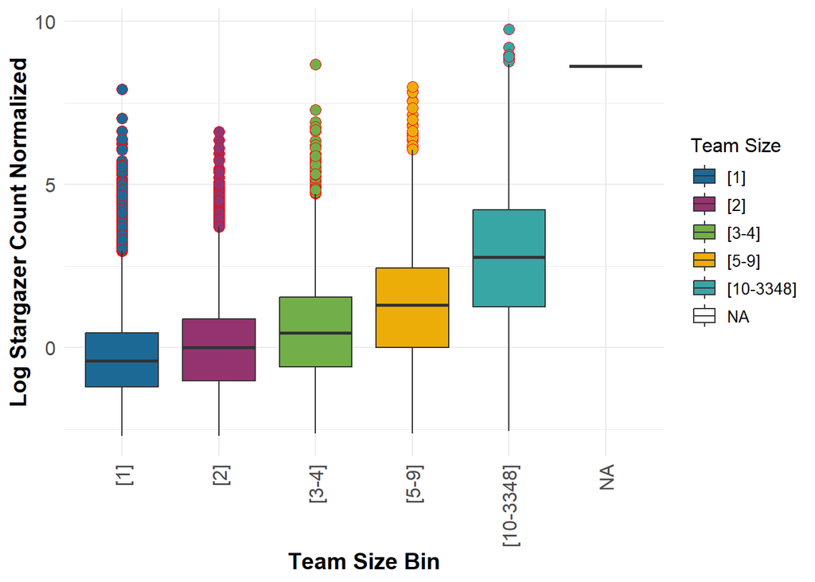

```r
# Define a custom theme
custom_theme <- theme_minimal() +
  theme(
    axis.text.x = element_text(angle = 90, hjust = 1, vjust = 0.5, size = 12),
    axis.text.y = element_text(size = 12),
    axis.title = element_text(size = 14, face = "bold"),
    plot.title = element_text(size = 16, face = "bold", hjust = 0.5),
    legend.title = element_text(size = 12),
    legend.text = element_text(size = 10)
  )

# Plot stargazerCount_normalized vs. team_size_bin
ggplot(python_final_distinct, aes(x = team_size_bin, y = log(stargazerCount_normalized), fill = team_size_bin)) +
  geom_boxplot(outlier.color = "red", outlier.shape = 21, outlier.size = 3) +
  scale_fill_westat(option = "BLUES", drop = FALSE) +
  labs(x = "Team Size Bin", y = "Log Stargazer Count Normalized", fill = "Team Size") +
  custom_theme
```

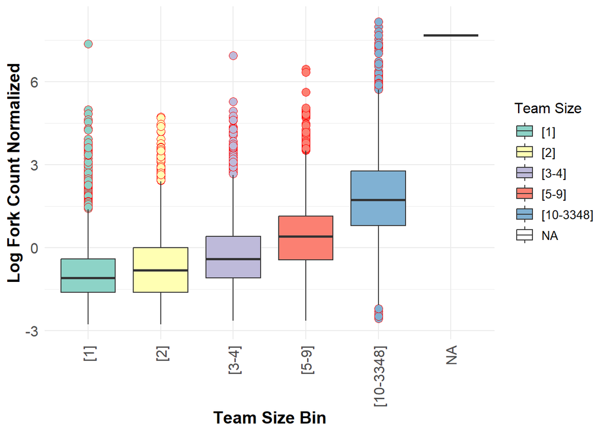

```r
# Plot forkCount_normalized vs. team_size_bin
ggplot(python_final_distinct, aes(x = team_size_bin, y = log(forkCount_normalized), fill = team_size_bin)) +
  geom_boxplot(outlier.color = "red", outlier.shape = 21, outlier.size = 3) +
  scale_fill_brewer(palette = "Set3") +
  labs(x = "Team Size Bin", y = "Log Fork Count Normalized", fill = "Team Size") +
  custom_theme
```

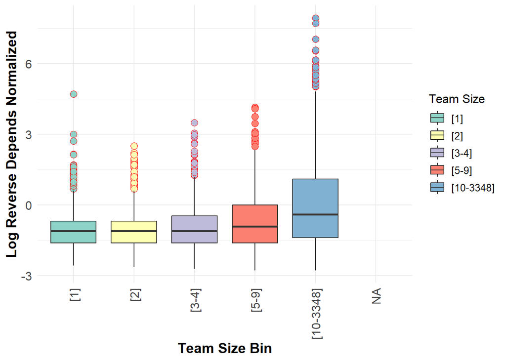

```r
# Plot RevDepCount vs. team_size_bin
ggplot(python_final_distinct, aes(x = team_size_bin, y = log(RevDepCount_normalized), fill = team_size_bin)) +
  geom_boxplot(outlier.color = "red", outlier.shape = 21, outlier.size = 3) +
  scale_fill_brewer(palette = "Set3") +
  labs(x = "Team Size Bin", y = "Log Reverse Depends Normalized", fill = "Team Size") +
  custom_theme
```

#### 2.3.2.2 non_normalized

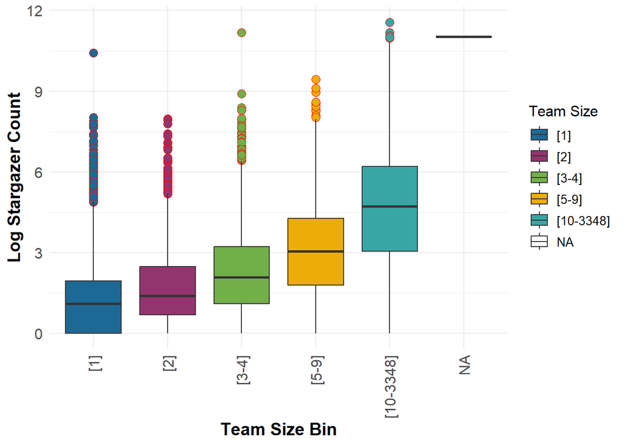

```r
# Define a custom theme
custom_theme <- theme_minimal() +
  theme(
    axis.text.x = element_text(angle = 90, hjust = 1, vjust = 0.5, size = 12),
    axis.text.y = element_text(size = 12),
    axis.title = element_text(size = 14, face = "bold"),
    plot.title = element_text(size = 16, face = "bold", hjust = 0.5),
    legend.title = element_text(size = 12),
    legend.text = element_text(size = 10)
  )

# Plot stargazerCount_normalized vs. team_size_bin
ggplot(python_final_distinct, aes(x = team_size_bin, y = log(stargazerCount), fill = team_size_bin)) +
  geom_boxplot(outlier.color = "red", outlier.shape = 21, outlier.size = 3) +
  scale_fill_westat(option = "BLUES", drop = FALSE) +
  labs(x = "Team Size Bin", y = "Log Stargazer Count", fill = "Team Size") +
  custom_theme
```

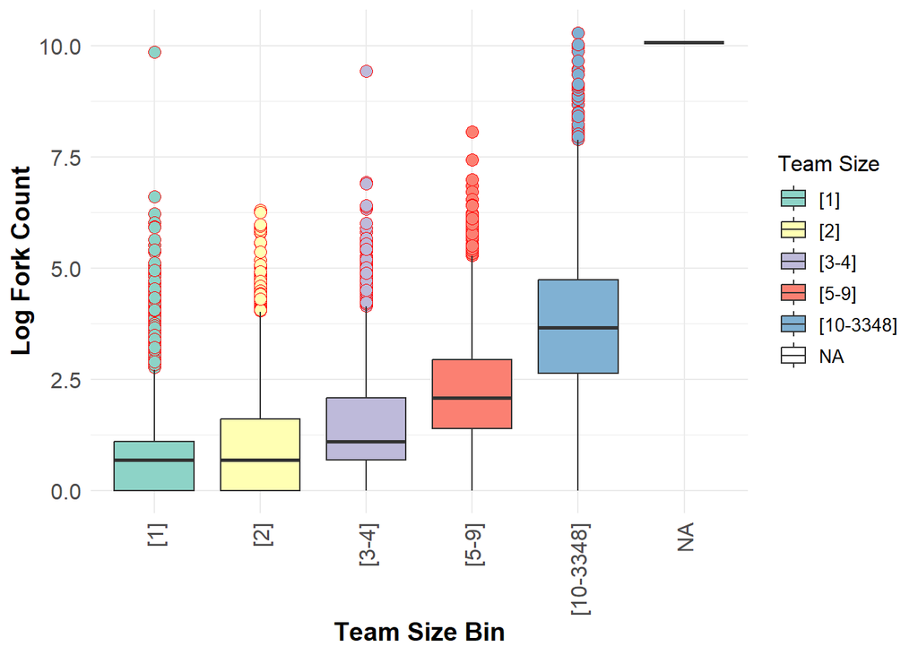

```r
# Plot forkCount_normalized vs. team_size_bin
ggplot(python_final_distinct, aes(x = team_size_bin, y = log(forkCount), fill = team_size_bin)) +
  geom_boxplot(outlier.color = "red", outlier.shape = 21, outlier.size = 3) +
  scale_fill_brewer(palette = "Set3") +
  labs(x = "Team Size Bin", y = "Log Fork Count", fill = "Team Size") +
  custom_theme
```

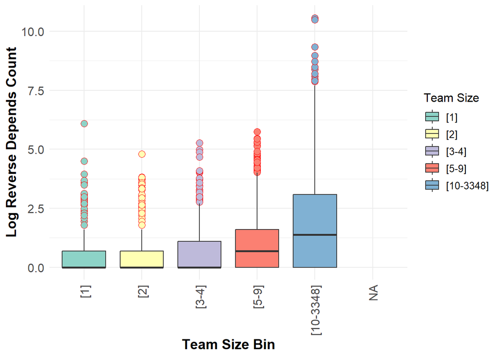

```r
# Plot RevDepCount vs. team_size_bin
ggplot(python_final_distinct, aes(x = team_size_bin, y = log(Reverse_Depends_Count), fill = team_size_bin)) +
  geom_boxplot(outlier.color = "red", outlier.shape = 21, outlier.size = 3) +
  scale_fill_brewer(palette = "Set3") +
  labs(x = "Team Size Bin", y = "Log Reverse Depends Count", fill = "Team Size") +
  custom_theme
```

### 2.3.3 boxplot viz (no outliers)

#### 2.3.3.1 normalized

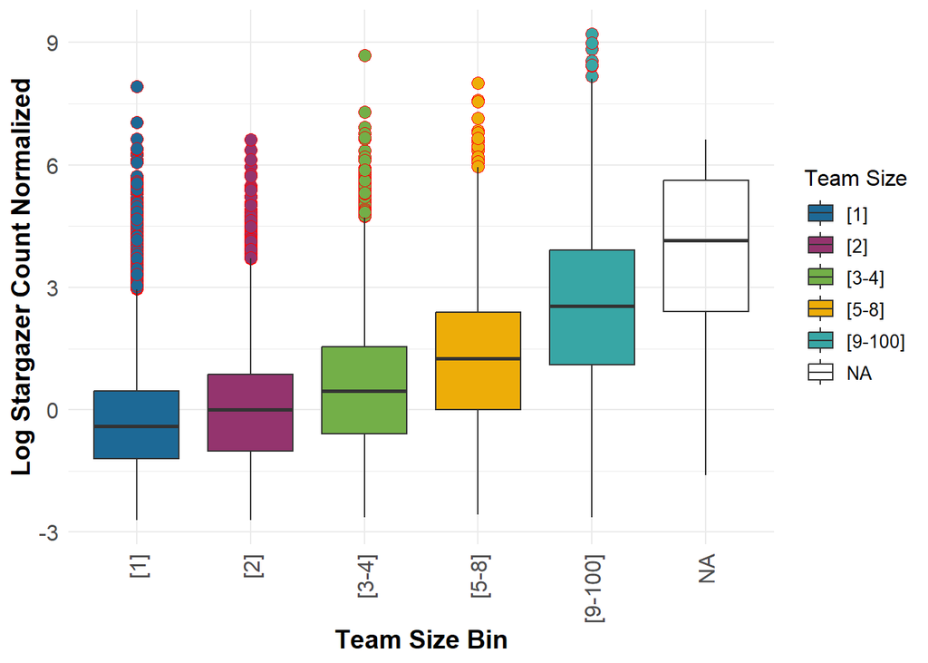

```r
# Define a custom theme
custom_theme <- theme_minimal() +
  theme(
    axis.text.x = element_text(angle = 90, hjust = 1, vjust = 0.5, size = 12),
    axis.text.y = element_text(size = 12),
    axis.title = element_text(size = 14, face = "bold"),
    plot.title = element_text(size = 16, face = "bold", hjust = 0.5),
    legend.title = element_text(size = 12),
    legend.text = element_text(size = 10)
  )

# Plot stargazerCount_normalized vs. team_size_bin
ggplot(python_final_distinct_z, aes(x = team_size_bin, y = log(stargazerCount_normalized), fill = team_size_bin)) +
  geom_boxplot(outlier.color = "red", outlier.shape = 21, outlier.size = 3) +
  scale_fill_westat(option = "BLUES", drop = FALSE) +
  labs(x = "Team Size Bin", y = "Log Stargazer Count Normalized", fill = "Team Size") +
  custom_theme
```

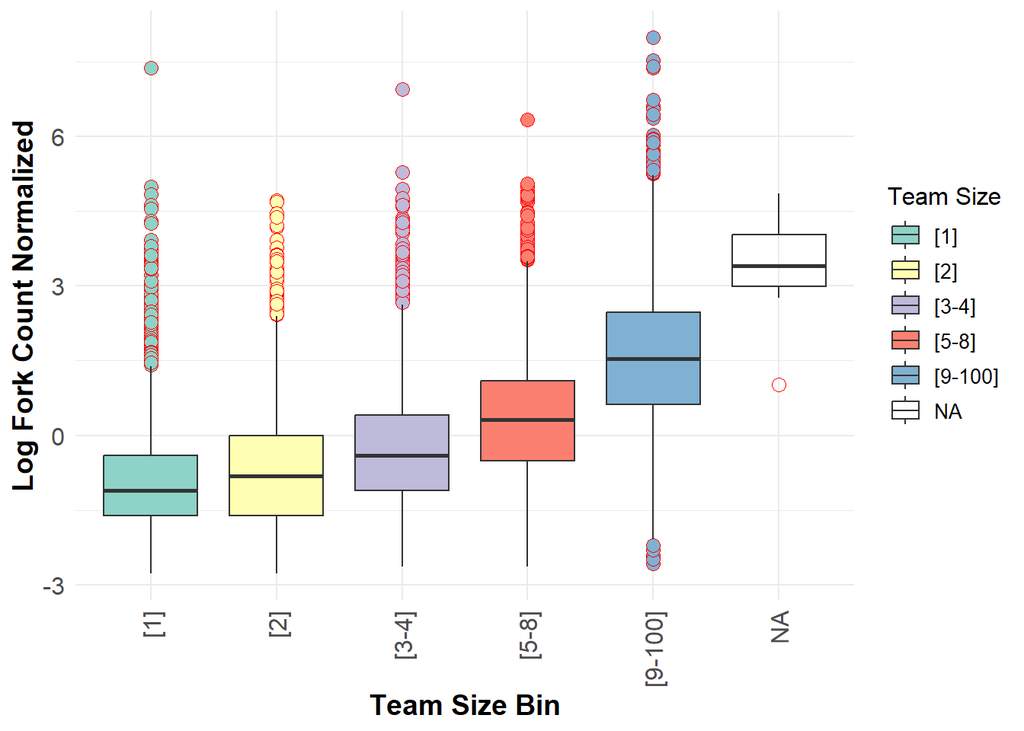

```r
# Plot forkCount_normalized vs. team_size_bin
ggplot(python_final_distinct_z, aes(x = team_size_bin, y = log(forkCount_normalized), fill = team_size_bin)) +
  geom_boxplot(outlier.color = "red", outlier.shape = 21, outlier.size = 3) +
  scale_fill_brewer(palette = "Set3") +
  labs(x = "Team Size Bin", y = "Log Fork Count Normalized", fill = "Team Size") +
  custom_theme
```

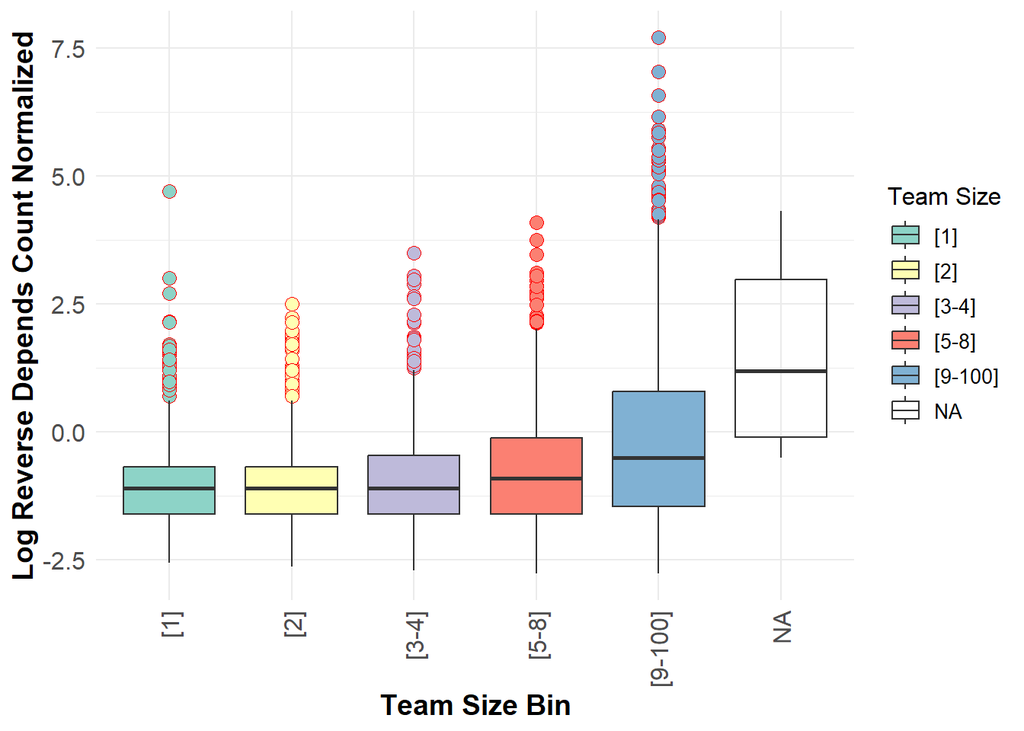

```r
# Plot RevDepCount vs. team_size_bin
ggplot(python_final_distinct_z, aes(x = team_size_bin, y = log(RevDepCount_normalized), fill = team_size_bin)) +
  geom_boxplot(outlier.color = "red", outlier.shape = 21, outlier.size = 3) +
  scale_fill_brewer(palette = "Set3") +
  labs(x = "Team Size Bin", y = "Log Reverse Depends Count Normalized", fill = "Team Size") +
  custom_theme
```

#### 2.3.3.2 non-normalized

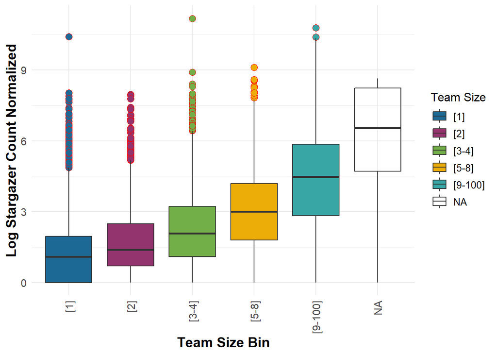

```r
# Define a custom theme
custom_theme <- theme_minimal() +
  theme(
    axis.text.x = element_text(angle = 90, hjust = 1, vjust = 0.5, size = 11),
    axis.text.y = element_text(size = 11),
    axis.title = element_text(size = 14, face = "bold"),
    plot.title = element_text(size = 16, face = "bold", hjust = 0.5),
    legend.title = element_text(size = 12),
    legend.text = element_text(size = 10)
  )

# Plot stargazerCount_normalized vs. team_size_bin
ggplot(python_final_distinct_z, aes(x = team_size_bin, y = log(stargazerCount), fill = team_size_bin)) +
  geom_boxplot(outlier.color = "red", outlier.shape = 21, outlier.size = 3) +
  scale_fill_westat(option = "BLUES", drop = FALSE) +
  labs(x = "Team Size Bin", y = "Log Stargazer Count Normalized", fill = "Team Size") +
  custom_theme
```

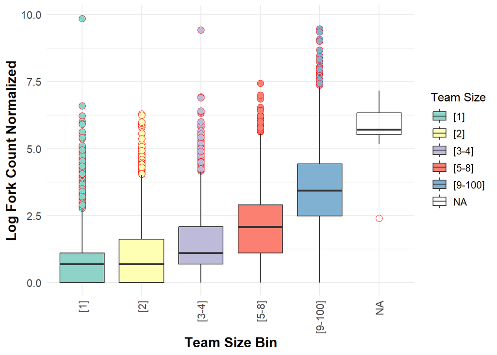

```r
# Plot forkCount_normalized vs. team_size_bin
ggplot(python_final_distinct_z, aes(x = team_size_bin, y = log(forkCount), fill = team_size_bin)) +
  geom_boxplot(outlier.color = "red", outlier.shape = 21, outlier.size = 3) +
  scale_fill_brewer(palette = "Set3") +
  labs(x = "Team Size Bin", y = "Log Fork Count Normalized", fill = "Team Size") +
  custom_theme
```

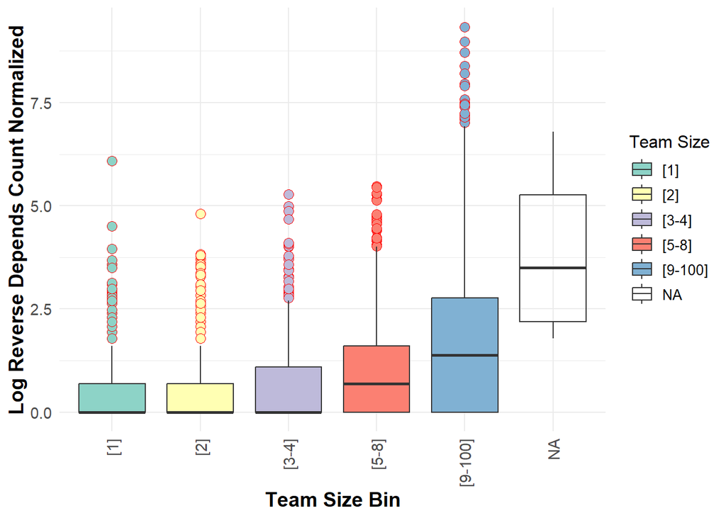

```r
# Plot RevDepCount vs. team_size_bin
ggplot(python_final_distinct_z, aes(x = team_size_bin, y = log(Reverse_Depends_Count), fill = team_size_bin)) +
  geom_boxplot(outlier.color = "red", outlier.shape = 21, outlier.size = 3) +
  scale_fill_brewer(palette = "Set3") +
  labs(x = "Team Size Bin", y = "Log Reverse Depends Count Normalized", fill = "Team Size") +
  custom_theme
```

### 2.3.4 correlation viz (with outliers)

#### 2.3.4.1 normalized

```r
# Calculate correlation between team_size and the normalized counts
correlation_matrix <- python_final_distinct %>%
  select(team_size, forkCount_normalized, stargazerCount_normalized, RevDepCount_normalized) %>%
  cor(use = "complete.obs")

# View the correlation matrix
print(correlation_matrix)
```

```
                          team_size forkCount_normalized
team_size                 1.0000000            0.6067797
forkCount_normalized      0.6067797            1.0000000
stargazerCount_normalized 0.5213794            0.8329639
RevDepCount_normalized    0.2058146            0.1110238
                          stargazerCount_normalized RevDepCount_normalized
team_size                                 0.5213794              0.2058146
forkCount_normalized                      0.8329639              0.1110238
stargazerCount_normalized                 1.0000000              0.1219406
RevDepCount_normalized                    0.1219406              1.0000000
```

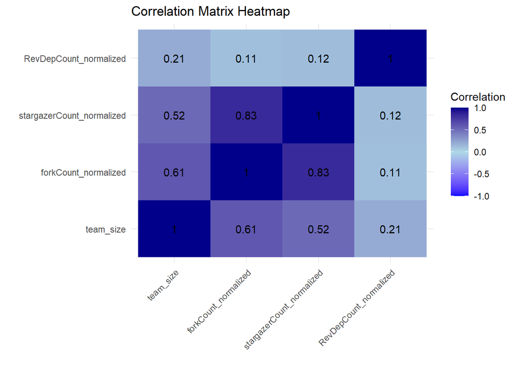

```r
library(reshape2)
# Melt the correlation matrix
melted_correlation_matrix <- melt(correlation_matrix)

ggplot(data = melted_correlation_matrix, aes(x = Var1, y = Var2, fill = value)) +
  geom_tile() +
  geom_text(aes(label = round(value, 2)), color = "black") +
  scale_fill_gradient2(low = "blue", high = "darkblue", mid = "lightblue", midpoint = 0, limit = c(-1, 1), space = "Lab", name="Correlation") +
  theme_minimal() +
  theme(axis.text.x = element_text(angle = 45, vjust = 1, hjust = 1)) +
  labs(title = "Correlation Matrix Heatmap", x = "", y = "")
```

#### 2.3.4.2 non-normalized

```r
# Calculate correlation between team_size and the normalized counts
correlation_matrix <- python_final_distinct %>%
  select(team_size, forkCount, stargazerCount, Reverse_Depends_Count) %>%
  cor(use = "complete.obs")

# View the correlation matrix
print(correlation_matrix)
```

```
                      team_size forkCount stargazerCount Reverse_Depends_Count
team_size             1.0000000 0.6798705      0.6297321             0.2288878
forkCount             0.6798705 1.0000000      0.8841083             0.1851289
stargazerCount        0.6297321 0.8841083      1.0000000             0.2087869
Reverse_Depends_Count 0.2288878 0.1851289      0.2087869             1.0000000
```

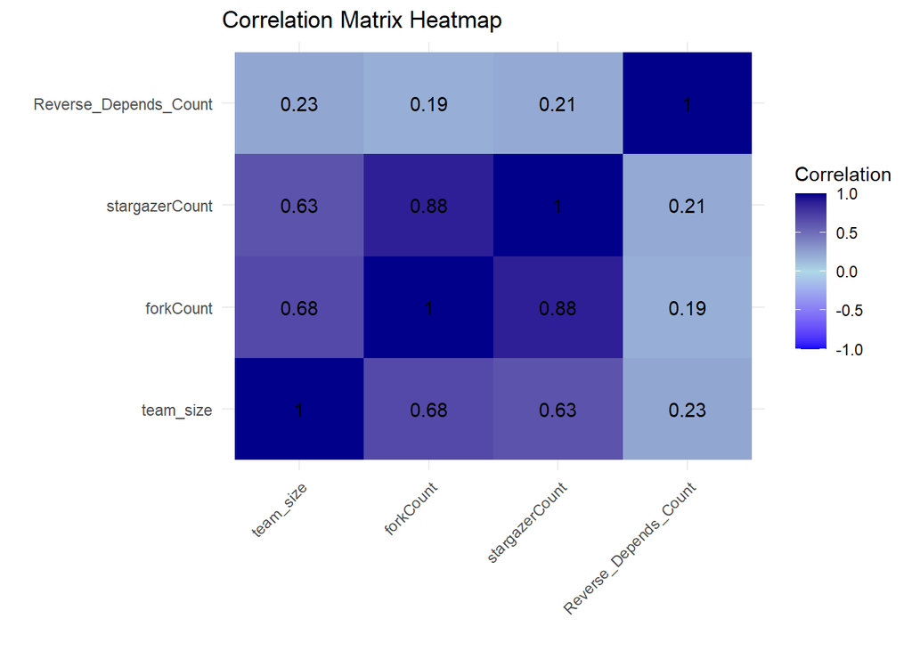

```r
# Melt the correlation matrix
melted_correlation_matrix <- melt(correlation_matrix)

ggplot(data = melted_correlation_matrix, aes(x = Var1, y = Var2, fill = value)) +
  geom_tile() +
  geom_text(aes(label = round(value, 2)), color = "black") +
  scale_fill_gradient2(low = "blue", high = "darkblue", mid = "lightblue", midpoint = 0, limit = c(-1, 1), space = "Lab", name="Correlation") +
  theme_minimal() +
  theme(axis.text.x = element_text(angle = 45, vjust = 1, hjust = 1)) +
  labs(title = "Correlation Matrix Heatmap", x = "", y = "")
```

### 2.3.5 correlation viz (no outliers)

#### 2.3.5.1 normalized

```r
# Calculate correlation between team_size and the normalized counts
correlation_matrix <- python_final_distinct_z %>%
  select(team_size, forkCount_normalized, stargazerCount_normalized, RevDepCount_normalized) %>%
  cor(use = "complete.obs")

# View the correlation matrix
print(correlation_matrix)
```

```
                          team_size forkCount_normalized
team_size                 1.0000000           0.24255965
forkCount_normalized      0.2425597           1.00000000
stargazerCount_normalized 0.2833555           0.71796015
RevDepCount_normalized    0.1219360           0.02924279
                          stargazerCount_normalized RevDepCount_normalized
team_size                                0.28335545             0.12193598
forkCount_normalized                     0.71796015             0.02924279
stargazerCount_normalized                1.00000000             0.04869488
RevDepCount_normalized                   0.04869488             1.00000000
```

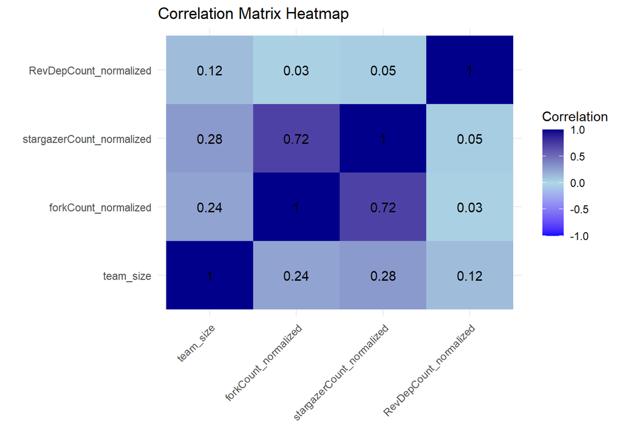

```r
# Melt the correlation matrix
melted_correlation_matrix <- melt(correlation_matrix)

ggplot(data = melted_correlation_matrix, aes(x = Var1, y = Var2, fill = value)) +
  geom_tile() +
  geom_text(aes(label = round(value, 2)), color = "black") +
  scale_fill_gradient2(low = "blue", high = "darkblue", mid = "lightblue", midpoint = 0, limit = c(-1, 1), space = "Lab", name="Correlation") +
  theme_minimal() +
  theme(axis.text.x = element_text(angle = 45, vjust = 1, hjust = 1)) +
  labs(title = "Correlation Matrix Heatmap", x = "", y = "")
```

#### 2.3.5.2 non-normalized

```r
# Calculate correlation between team_size and the normalized counts
correlation_matrix <- python_final_distinct_z %>%
  select(team_size, forkCount, stargazerCount, Reverse_Depends_Count) %>%
  cor(use = "complete.obs")

# View the correlation matrix
print(correlation_matrix)
```

```
                      team_size  forkCount stargazerCount Reverse_Depends_Count
team_size             1.0000000 0.26410035     0.32789485            0.15057158
forkCount             0.2641004 1.00000000     0.82459372            0.04113711
stargazerCount        0.3278949 0.82459372     1.00000000            0.07855337
Reverse_Depends_Count 0.1505716 0.04113711     0.07855337            1.00000000
```

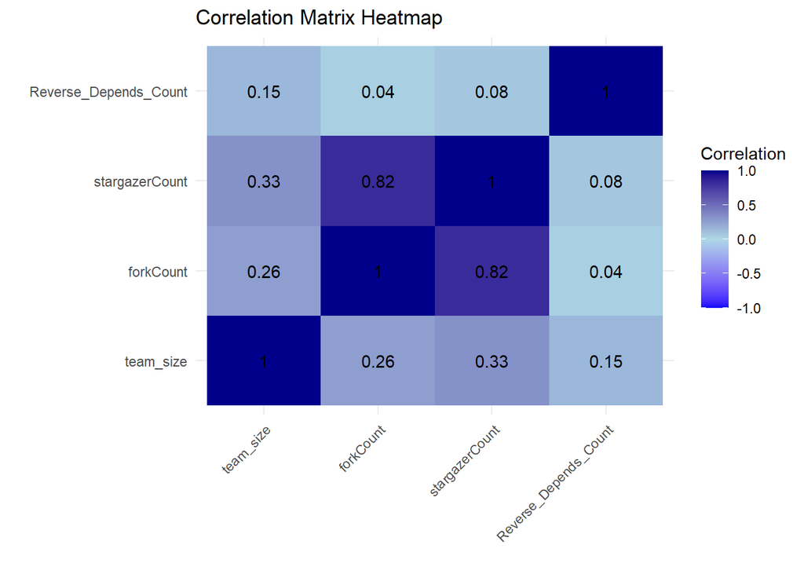

```r
# Melt the correlation matrix
melted_correlation_matrix <- melt(correlation_matrix)

ggplot(data = melted_correlation_matrix, aes(x = Var1, y = Var2, fill = value)) +
  geom_tile() +
  geom_text(aes(label = round(value, 2)), color = "black") +
  scale_fill_gradient2(low = "blue", high = "darkblue", mid = "lightblue", midpoint = 0, limit = c(-1, 1), space = "Lab", name="Correlation") +
  theme_minimal() +
  theme(axis.text.x = element_text(angle = 45, vjust = 1, hjust = 1)) +
  labs(title = "Correlation Matrix Heatmap", x = "", y = "")
```

### 2.3.6 models (continuous team_size w/ outliers)

#### 2.3.6.1 normalized

```r
library(broom)

# Filter out non-positive values and missing values
python_final_filtered1 <- python_final_distinct %>%
  filter(stargazerCount_normalized > 0, !is.na(stargazerCount_normalized),
         forkCount_normalized > 0, !is.na(forkCount_normalized),
         RevDepCount_normalized > 0, !is.na(RevDepCount_normalized))

# Perform linear regression and get summary and confidence intervals
model_stargazer <- lm(stargazerCount_normalized ~ team_size, data = python_final_filtered1)
model_fork <- lm(forkCount_normalized ~ team_size, data = python_final_filtered1)
model_revdep <- lm(RevDepCount_normalized ~ team_size, data = python_final_filtered1)

summary(model_stargazer)
```

```
Call:
lm(formula = stargazerCount_normalized ~ team_size, data = python_final_filtered1)

Residuals:
    Min      1Q  Median      3Q     Max
-3189.7   -40.2   -24.7   -16.2  9905.9

Coefficients:
            Estimate Std. Error t value Pr(>|t|)
(Intercept) 18.56931    3.52227   5.272 1.39e-07 ***
team_size    2.62321    0.05666  46.296  < 2e-16 ***
---
Signif. codes:  0 '***' 0.001 '**' 0.01 '*' 0.05 '.' 0.1 ' ' 1

Residual standard error: 270.6 on 6630 degrees of freedom
Multiple R-squared:  0.2443,    Adjusted R-squared:  0.2442
F-statistic:  2143 on 1 and 6630 DF,  p-value: < 2.2e-16
```

```r
confint(model_stargazer)
```

```
                2.5 %    97.5 %
(Intercept) 11.664527 25.474095
team_size    2.512132  2.734281
```

```r
summary(model_fork)
```

```
Call:
lm(formula = forkCount_normalized ~ team_size, data = python_final_filtered1)

Residuals:
    Min      1Q  Median      3Q     Max
-434.19   -5.32   -1.56   -0.01 1819.56

Coefficients:
            Estimate Std. Error t value Pr(>|t|)
(Intercept)  -0.0457     0.6463  -0.071    0.944
team_size     0.6544     0.0104  62.944   <2e-16 ***
---
Signif. codes:  0 '***' 0.001 '**' 0.01 '*' 0.05 '.' 0.1 ' ' 1

Residual standard error: 49.65 on 6630 degrees of freedom
Multiple R-squared:  0.3741,    Adjusted R-squared:  0.374
F-statistic:  3962 on 1 and 6630 DF,  p-value: < 2.2e-16
```

```r
confint(model_fork)
```

```
                 2.5 %    97.5 %
(Intercept) -1.3126575 1.2212497
team_size    0.6340314 0.6747933
```

```r
summary(model_revdep)
```

```
Call:
lm(formula = RevDepCount_normalized ~ team_size, data = python_final_filtered1)

Residuals:
    Min      1Q  Median      3Q     Max
-874.27   -2.66    0.54    1.74 2543.19

Coefficients:
            Estimate Std. Error t value Pr(>|t|)
(Intercept) -2.13224    0.76637  -2.782  0.00541 **
team_size    0.34925    0.01233  28.329  < 2e-16 ***
---
Signif. codes:  0 '***' 0.001 '**' 0.01 '*' 0.05 '.' 0.1 ' ' 1

Residual standard error: 58.88 on 6630 degrees of freedom
Multiple R-squared:  0.108, Adjusted R-squared:  0.1078
F-statistic: 802.5 on 1 and 6630 DF,  p-value: < 2.2e-16
```

```r
confint(model_revdep)
```

```
                 2.5 %     97.5 %
(Intercept) -3.6345824 -0.6299000
team_size    0.3250787  0.3734138
```

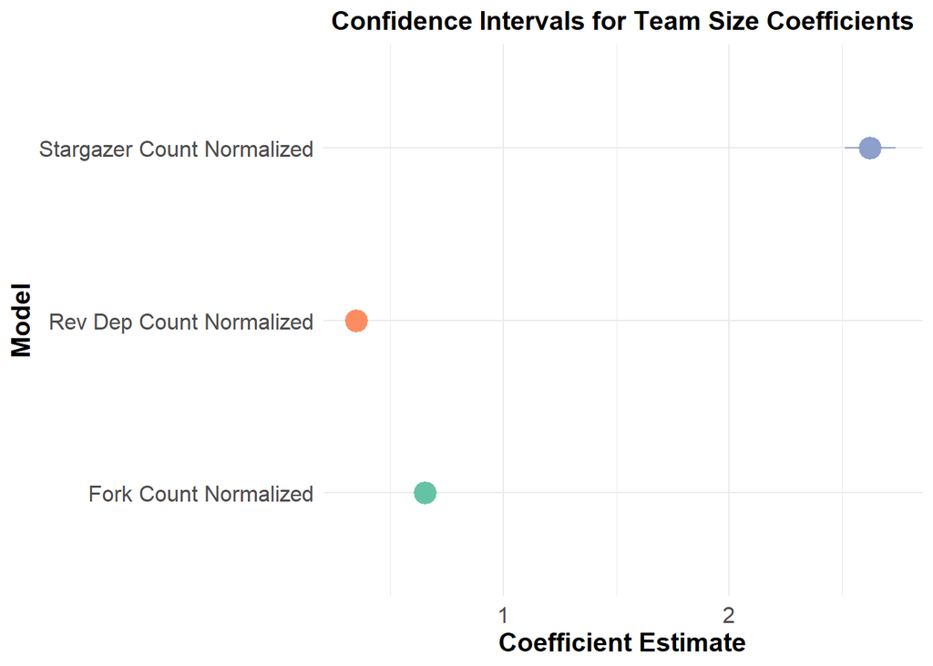

```r
# Tidy the models
tidy_stargazer <- tidy(model_stargazer, conf.int = TRUE)
tidy_fork <- tidy(model_fork, conf.int = TRUE)
tidy_revdep <- tidy(model_revdep, conf.int = TRUE)

# Combine the tidied data
tidy_combined <- bind_rows(
  tidy_stargazer %>% mutate(model = "Stargazer Count Normalized"),
  tidy_fork %>% mutate(model = "Fork Count Normalized"),
  tidy_revdep %>% mutate(model = "Rev Dep Count Normalized")
)

# Filter out the intercept terms
tidy_combined <- tidy_combined %>% filter(term == "team_size")

# Determine y-axis limits to ensure visibility of confidence intervals
y_limits <- range(tidy_combined$conf.low, tidy_combined$conf.high)

# Create the plot
ggplot(tidy_combined, aes(x = model, y = estimate, ymin = conf.low, ymax = conf.high, color = model)) +
  geom_pointrange(size = 1.2) +
  geom_point(size = 3) +
  geom_vline(xintercept = 0, linetype = "dashed", color = "gray") +
  coord_flip() +
  scale_y_continuous(limits = y_limits) + # Adjust the limits based on confidence intervals
  labs(title = "Confidence Intervals for Team Size Coefficients",
       x = "Model",
       y = "Coefficient Estimate") +
  theme_minimal() +
  theme(
    plot.title = element_text(size = 14, face = "bold", hjust = 0.5), # Reduce title size
    axis.title.x = element_text(size = 14, face = "bold"),
    axis.title.y = element_text(size = 14, face = "bold"),
    axis.text = element_text(size = 12),
    legend.position = "none"
  ) +
  scale_color_brewer(palette = "Set2")
```

#### 2.3.6.2 non-normalized

```r
# Filter out non-positive values and missing values
python_final_filtered2 <- python_final_distinct %>%
  filter(stargazerCount > 0, !is.na(stargazerCount),
         forkCount > 0, !is.na(forkCount),
         Reverse_Depends_Count > 0, !is.na(Reverse_Depends_Count))

# Perform linear regression and get summary and confidence intervals
model_stargazer <- lm(stargazerCount ~ team_size, data = python_final_filtered2)
model_fork <- lm(forkCount ~ team_size, data = python_final_filtered2)
model_revdep <- lm(Reverse_Depends_Count ~ team_size, data = python_final_filtered2)

summary(model_stargazer)
```

```
Call:
lm(formula = stargazerCount ~ team_size, data = python_final_filtered2)

Residuals:
   Min     1Q Median     3Q    Max
-31355   -250    -93    -33  71523

Coefficients:
            Estimate Std. Error t value Pr(>|t|)
(Intercept)  19.7580    25.3572   0.779    0.436
team_size    24.7220     0.4079  60.606   <2e-16 ***
---
Signif. codes:  0 '***' 0.001 '**' 0.01 '*' 0.05 '.' 0.1 ' ' 1

Residual standard error: 1948 on 6630 degrees of freedom
Multiple R-squared:  0.3565,    Adjusted R-squared:  0.3564
F-statistic:  3673 on 1 and 6630 DF,  p-value: < 2.2e-16
```

```r
confint(model_stargazer)
```

```
                2.5 %   97.5 %
(Intercept) -29.95035 69.46635
team_size    23.92231 25.52159
```

```r
summary(model_fork)
```

```
Call:
lm(formula = forkCount ~ team_size, data = python_final_filtered2)

Residuals:
    Min      1Q  Median      3Q     Max
-3230.8   -36.7     3.7    20.6 12670.6

Coefficients:
             Estimate Std. Error t value Pr(>|t|)
(Intercept) -25.86708    5.03790  -5.134 2.91e-07 ***
team_size     6.28261    0.08104  77.522  < 2e-16 ***
---
Signif. codes:  0 '***' 0.001 '**' 0.01 '*' 0.05 '.' 0.1 ' ' 1

Residual standard error: 387.1 on 6630 degrees of freedom
Multiple R-squared:  0.4755,    Adjusted R-squared:  0.4754
F-statistic:  6010 on 1 and 6630 DF,  p-value: < 2.2e-16
```

```r
confint(model_fork)
```

```
                 2.5 %     97.5 %
(Intercept) -35.742995 -15.991166
team_size     6.123745   6.441485
```

```r
summary(model_revdep)
```

```
Call:
lm(formula = Reverse_Depends_Count ~ team_size, data = python_final_filtered2)

Residuals:
   Min     1Q Median     3Q    Max
-11058    -20     23     40  33157

Coefficients:
            Estimate Std. Error t value Pr(>|t|)
(Intercept) -47.9610     8.4311  -5.689 1.34e-08 ***
team_size     4.4247     0.1356  32.624  < 2e-16 ***
---
Signif. codes:  0 '***' 0.001 '**' 0.01 '*' 0.05 '.' 0.1 ' ' 1

Residual standard error: 647.7 on 6630 degrees of freedom
Multiple R-squared:  0.1383,    Adjusted R-squared:  0.1382
F-statistic:  1064 on 1 and 6630 DF,  p-value: < 2.2e-16
```

```r
confint(model_revdep)
```

```
                 2.5 %     97.5 %
(Intercept) -64.488720 -31.433278
team_size     4.158856   4.690606
```

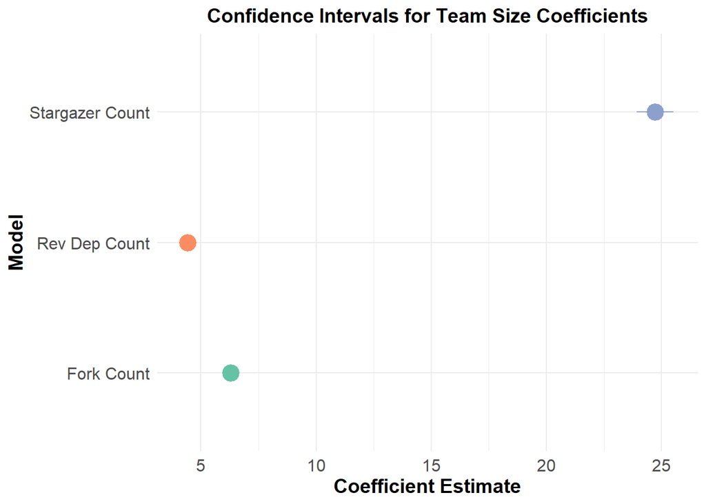

```r
# Tidy the models
tidy_stargazer <- tidy(model_stargazer, conf.int = TRUE)
tidy_fork <- tidy(model_fork, conf.int = TRUE)
tidy_revdep <- tidy(model_revdep, conf.int = TRUE)

# Combine the tidied data
tidy_combined <- bind_rows(
  tidy_stargazer %>% mutate(model = "Stargazer Count"),
  tidy_fork %>% mutate(model = "Fork Count"),
  tidy_revdep %>% mutate(model = "Rev Dep Count")
)

# Filter out the intercept terms
tidy_combined <- tidy_combined %>% filter(term == "team_size")

# Determine y-axis limits to ensure visibility of confidence intervals
y_limits <- range(tidy_combined$conf.low, tidy_combined$conf.high)

# Create the plot
ggplot(tidy_combined, aes(x = model, y = estimate, ymin = conf.low, ymax = conf.high, color = model)) +
  geom_pointrange(size = 1.2) +
  geom_point(size = 3) +
  geom_vline(xintercept = 0, linetype = "dashed", color = "gray") +
  coord_flip() +
  scale_y_continuous(limits = y_limits) + # Adjust the limits based on confidence intervals
  labs(title = "Confidence Intervals for Team Size Coefficients",
       x = "Model",
       y = "Coefficient Estimate") +
  theme_minimal() +
  theme(
    plot.title = element_text(size = 14, face = "bold", hjust = 0.5), # Reduce title size
    axis.title.x = element_text(size = 14, face = "bold"),
    axis.title.y = element_text(size = 14, face = "bold"),
    axis.text = element_text(size = 12),
    legend.position = "none"
  ) +
  scale_color_brewer(palette = "Set2")
```

### 2.3.7 models (continuous team_size w/o outliers)

#### 2.3.7.1 normalized

```r
# Filter out non-positive values and missing values
python_final_filtered3 <- python_final_distinct_z %>%
  filter(stargazerCount_normalized > 0, !is.na(stargazerCount_normalized),
         forkCount_normalized > 0, !is.na(forkCount_normalized),
         RevDepCount_normalized > 0, !is.na(RevDepCount_normalized))

# Perform linear regression and get summary and confidence intervals
model_stargazer <- lm(stargazerCount_normalized ~ team_size, data = python_final_filtered3)
model_fork <- lm(forkCount_normalized ~ team_size, data = python_final_filtered3)
model_revdep <- lm(RevDepCount_normalized ~ team_size, data = python_final_filtered3)

summary(model_stargazer)
```

```
Call:
lm(formula = stargazerCount_normalized ~ team_size, data = python_final_filtered3)

Residuals:
   Min     1Q Median     3Q    Max
-336.0  -34.5  -14.4   -5.8 9911.6

Coefficients:
            Estimate Std. Error t value Pr(>|t|)
(Intercept)   4.9436     3.4792   1.421    0.155
team_size     3.3415     0.1601  20.871   <2e-16 ***
---
Signif. codes:  0 '***' 0.001 '**' 0.01 '*' 0.05 '.' 0.1 ' ' 1

Residual standard error: 217.1 on 6407 degrees of freedom
Multiple R-squared:  0.06366,   Adjusted R-squared:  0.06351
F-statistic: 435.6 on 1 and 6407 DF,  p-value: < 2.2e-16
```

```r
confint(model_stargazer)
```

```
                2.5 %    97.5 %
(Intercept) -1.876753 11.764029
team_size    3.027652  3.655365
```

```r
summary(model_fork)
```

```
Call:
lm(formula = forkCount_normalized ~ team_size, data = python_final_filtered3)

Residuals:
    Min      1Q  Median      3Q     Max
 -59.33   -5.01   -1.99   -0.56 1821.35

Coefficients:
            Estimate Std. Error t value Pr(>|t|)
(Intercept)  0.70190    0.60066   1.169    0.243
team_size    0.60754    0.02764  21.980   <2e-16 ***
---
Signif. codes:  0 '***' 0.001 '**' 0.01 '*' 0.05 '.' 0.1 ' ' 1

Residual standard error: 37.48 on 6407 degrees of freedom
Multiple R-squared:  0.07012,   Adjusted R-squared:  0.06997
F-statistic: 483.1 on 1 and 6407 DF,  p-value: < 2.2e-16
```

```r
confint(model_fork)
```

```
                 2.5 %    97.5 %
(Intercept) -0.4755895 1.8793974
team_size    0.5533594 0.6617296
```

```r
summary(model_revdep)
```

```
Call:
lm(formula = RevDepCount_normalized ~ team_size, data = python_final_filtered3)

Residuals:
    Min      1Q  Median      3Q     Max
 -30.15   -3.06   -0.51    0.47 2188.63

Coefficients:
            Estimate Std. Error t value Pr(>|t|)
(Intercept) -0.71441    0.60281  -1.185    0.236
team_size    0.30845    0.02774  11.119   <2e-16 ***
---
Signif. codes:  0 '***' 0.001 '**' 0.01 '*' 0.05 '.' 0.1 ' ' 1

Residual standard error: 37.61 on 6407 degrees of freedom
Multiple R-squared:  0.01893,   Adjusted R-squared:  0.01878
F-statistic: 123.6 on 1 and 6407 DF,  p-value: < 2.2e-16
```

```r
confint(model_revdep)
```

```
                2.5 %    97.5 %
(Intercept) -1.896133 0.4673046
team_size    0.254069 0.3628281
```

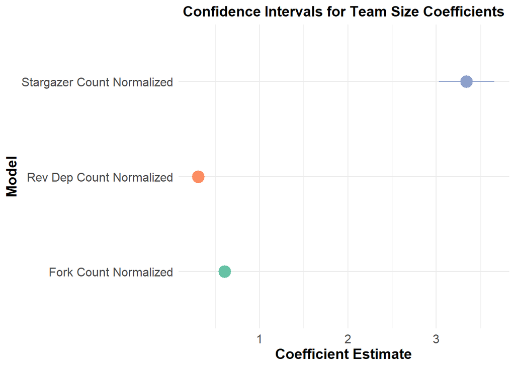

```r
# Tidy the models
tidy_stargazer <- tidy(model_stargazer, conf.int = TRUE)
tidy_fork <- tidy(model_fork, conf.int = TRUE)
tidy_revdep <- tidy(model_revdep, conf.int = TRUE)

# Combine the tidied data
tidy_combined <- bind_rows(
  tidy_stargazer %>% mutate(model = "Stargazer Count Normalized"),
  tidy_fork %>% mutate(model = "Fork Count Normalized"),
  tidy_revdep %>% mutate(model = "Rev Dep Count Normalized")
)

# Filter out the intercept terms
tidy_combined <- tidy_combined %>% filter(term == "team_size")

# Determine y-axis limits to ensure visibility of confidence intervals
y_limits <- range(tidy_combined$conf.low, tidy_combined$conf.high)

# Create the plot
ggplot(tidy_combined, aes(x = model, y = estimate, ymin = conf.low, ymax = conf.high, color = model)) +
  geom_pointrange(size = 1.2) +
  geom_point(size = 3) +
  geom_vline(xintercept = 0, linetype = "dashed", color = "gray") +
  coord_flip() +
  scale_y_continuous(limits = y_limits) + # Adjust the limits based on confidence intervals
  labs(title = "Confidence Intervals for Team Size Coefficients",
       x = "Model",
       y = "Coefficient Estimate") +
  theme_minimal() +
  theme(
    plot.title = element_text(size = 14, face = "bold", hjust = 0.5), # Reduce title size
    axis.title.x = element_text(size = 14, face = "bold"),
    axis.title.y = element_text(size = 14, face = "bold"),
    axis.text = element_text(size = 12),
    legend.position = "none"
  ) +
  scale_color_brewer(palette = "Set2")
```

#### 2.3.7.2 non-normalized

```r
# Filter out non-positive values and missing values
python_final_filtered4 <- python_final_distinct_z %>%
  filter(stargazerCount > 0, !is.na(stargazerCount),
         forkCount > 0, !is.na(forkCount),
         Reverse_Depends_Count > 0, !is.na(Reverse_Depends_Count))

# Perform linear regression and get summary and confidence intervals
model_stargazer <- lm(stargazerCount ~ team_size, data = python_final_filtered4)
model_fork <- lm(forkCount ~ team_size, data = python_final_filtered4)
model_revdep <- lm(Reverse_Depends_Count ~ team_size, data = python_final_filtered4)

summary(model_stargazer)
```

```
Call:
lm(formula = stargazerCount ~ team_size, data = python_final_filtered4)

Residuals:
   Min     1Q Median     3Q    Max
 -2489   -214    -65     -7  71551

Coefficients:
            Estimate Std. Error t value Pr(>|t|)
(Intercept)   -9.779     22.515  -0.434    0.664
team_size     25.234      1.036  24.355   <2e-16 ***
---
Signif. codes:  0 '***' 0.001 '**' 0.01 '*' 0.05 '.' 0.1 ' ' 1

Residual standard error: 1405 on 6407 degrees of freedom
Multiple R-squared:  0.08474,   Adjusted R-squared:  0.0846
F-statistic: 593.2 on 1 and 6407 DF,  p-value: < 2.2e-16
```

```r
confint(model_stargazer)
```

```
                2.5 %   97.5 %
(Intercept) -53.91477 34.35749
team_size    23.20272 27.26478
```

```r
summary(model_fork)
```

```
Call:
lm(formula = forkCount ~ team_size, data = python_final_filtered4)

Residuals:
    Min      1Q  Median      3Q     Max
 -453.3   -33.9   -10.6    -0.5 12730.7

Coefficients:
            Estimate Std. Error t value Pr(>|t|)
(Intercept)  -1.5160     4.1905  -0.362    0.718
team_size     4.7182     0.1928  24.468   <2e-16 ***
---
Signif. codes:  0 '***' 0.001 '**' 0.01 '*' 0.05 '.' 0.1 ' ' 1

Residual standard error: 261.5 on 6407 degrees of freedom
Multiple R-squared:  0.08545,   Adjusted R-squared:  0.08531
F-statistic: 598.7 on 1 and 6407 DF,  p-value: < 2.2e-16
```

```r
confint(model_fork)
```

```
                2.5 %   97.5 %
(Intercept) -9.730694 6.698698
team_size    4.340161 5.096198
```

```r
summary(model_revdep)
```

```
Call:
lm(formula = Reverse_Depends_Count ~ team_size, data = python_final_filtered4)

Residuals:
    Min      1Q  Median      3Q     Max
 -220.0   -21.8    -3.1     3.1 11118.1

Coefficients:
            Estimate Std. Error t value Pr(>|t|)
(Intercept)  -6.6082     3.5319  -1.871   0.0614 .
team_size     2.2764     0.1625  14.006   <2e-16 ***
---
Signif. codes:  0 '***' 0.001 '**' 0.01 '*' 0.05 '.' 0.1 ' ' 1

Residual standard error: 220.4 on 6407 degrees of freedom
Multiple R-squared:  0.02971,   Adjusted R-squared:  0.02956
F-statistic: 196.2 on 1 and 6407 DF,  p-value: < 2.2e-16
```

```r
confint(model_revdep)
```

```
                 2.5 %    97.5 %
(Intercept) -13.531885 0.3155443
team_size     1.957764 2.5949860
```

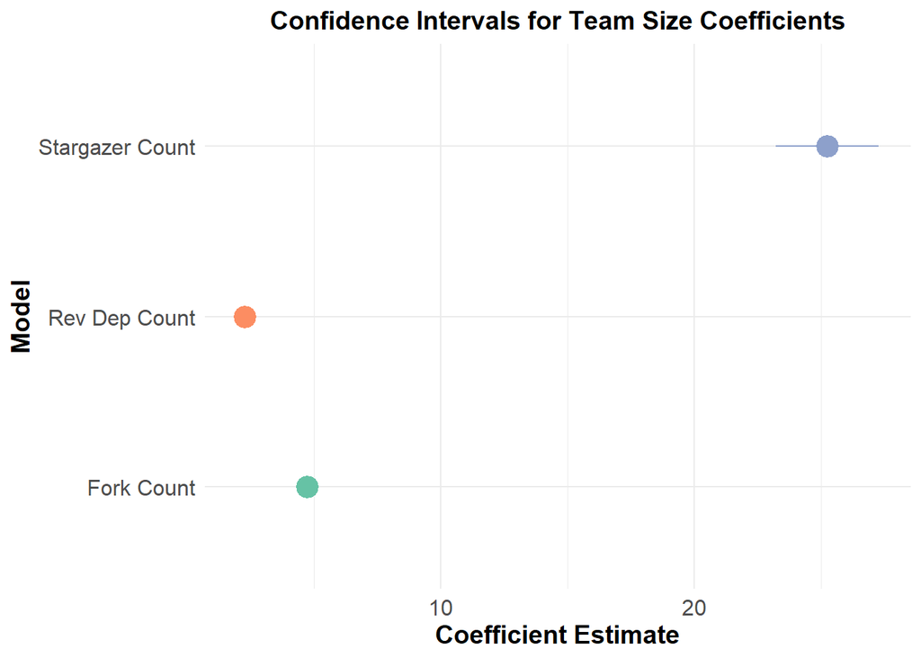

```r
# Tidy the models
tidy_stargazer <- tidy(model_stargazer, conf.int = TRUE)
tidy_fork <- tidy(model_fork, conf.int = TRUE)
tidy_revdep <- tidy(model_revdep, conf.int = TRUE)

# Combine the tidied data
tidy_combined <- bind_rows(
  tidy_stargazer %>% mutate(model = "Stargazer Count"),
  tidy_fork %>% mutate(model = "Fork Count"),
  tidy_revdep %>% mutate(model = "Rev Dep Count")
)

# Filter out the intercept terms
tidy_combined <- tidy_combined %>% filter(term == "team_size")

# Determine y-axis limits to ensure visibility of confidence intervals
y_limits <- range(tidy_combined$conf.low, tidy_combined$conf.high)

# Create the plot
ggplot(tidy_combined, aes(x = model, y = estimate, ymin = conf.low, ymax = conf.high, color = model)) +
  geom_pointrange(size = 1.2) +
  geom_point(size = 3) +
  geom_vline(xintercept = 0, linetype = "dashed", color = "gray") +
  coord_flip() +
  scale_y_continuous(limits = y_limits) + # Adjust the limits based on confidence intervals
  labs(title = "Confidence Intervals for Team Size Coefficients",
       x = "Model",
       y = "Coefficient Estimate") +
  theme_minimal() +
  theme(
    plot.title = element_text(size = 14, face = "bold", hjust = 0.5), # Reduce title size
    axis.title.x = element_text(size = 14, face = "bold"),
    axis.title.y = element_text(size = 14, face = "bold"),
    axis.text = element_text(size = 12),
    legend.position = "none"
  ) +
  scale_color_brewer(palette = "Set2")
```